# Project 09 - Exploratory Data Analytics

National Enrolment Dataset (2005 - 2017)

Doungporn Wiwatanapataphee

17 September 2019

# Introduction

There are many reasons why Australia has been one of the top study destinations for both domestic and international students in the past few decades. This is because of a safe and multicultural society together with a strong economic and low unemployment rate that attract students all across the globe. With an existing of the Group of Eight (Go8), the top reseach-intensive universities which rank in the top 100 of QS World University Rankings, the number of student enrolments has been considerably increase (Studies in Australia, n.d.).

However, with an increasing number of students, we lack an information about the factors affecting student enrolment behavior. This information might be useful in making an advertisement towards each particular target group of students, or at least give the institution the insight information of the student enrolment trends in the upcoming years.

There are many research questions arising from the enrolment dataset which can be investigate further in the following sections.

**Below is a list of some potential questions (**please click!**):**

1. Domestic VS International
   1. Which field of study and institution are the most popular among domestic (international) students? And what rank is UWA compared to other institutions.
   2. Which group of students, domestic or international, tend to study undergraduate degree, postgraduate degree by coursework or higher degree by research?
   3. For domestic students, which fields and institutions did the top students with ATAR 99 and above choose to study? What about the other groups of students with different ATAR? And what is the most common student’s ATAR found at UWA?
   4. International students from which region are the most common to be found studying in Australia? What about at UWA?
2. Disability VS Not disability
   1. Are students with disability more likely to study part-time?
   2. Which course and institution is the most popular among disabled and non-disabled students?
3. Low socioeconomic status VS Not low socioeconomic status
   1. Are students with low socioeconomic status more likely to study part-time? Or at college instead of Go8 or non-Go8 institutions?
4. Female vs Male
   1. Which group of students, male or female, tend to study Master or PhD?
5. Young Adults (<30 year-old) VS Adults ( $\geq$ 30 year-old)
   1. Which field of study is the most popular among young adults and adults?

In this project, an exploratory data analytics based on **National Enrolment Dataset** from year 2005 to 2017 is conducted. The National Enrolment Dataset is distributed by the University of Western Australia as a part of the CITS4009 Introduction to Data Science assessment. The entire dataset spans across 13 years (2005 to 2017), covers 41 Australian institutions. With a total of 12896962 records, a stratified dataset with 1% records from each institution is then obtained to make the assessment more accessible. This dataset provides data on 128967 students with 46 attributes.

**This dataset contains the following attributes (**please click!**):**

1. **X**: Ordered number (1 to 128967 observations)
2. **Year**: Reference Year from 2005 to 2017
3. **state**: State/Territory of Institution code (ACT, MUL(Multi-State), NSW, NT, QLD, SA, TAS, VIC, and WA)
4. **instutution_code**: Institution’s code number
5. **Institution**: Institution name
6. **Institution_Type**: There are three institution types which are *College*, *Group-of-Eight University* (Go8 University) and *Non-Group-of-Eight University* (Non-Go8 University). The Group of Eight (Go8) comprises Australia’s leading research-intensive universities - the University of Melbourne, the Australian National University, the University of Sydney, the University of Queensland, the University of Western Australia, the University of Adelaide, Monash University and UNSW Sydney (“The Group of Eight Ltd”, n.d.) .
7. **broad_course_type**: There are three broad course types which are *Undergraduate*, *Postgraduate Coursework* and *Higher Degree Research*.
8. **course_type**: Course of study type
9. **gender**: Females or Males
10. **age**: Student age as at reference year
11. **Commencing**: Commencing or Not commencing
12. **overseas**: Domestic (citizen/resident) or Overseas
13. **indigenous**: Indigenous (Aboriginal and Torres Strait Islander) or Not-Indigenous
14. **attendance_type**: Full-time or Part-time
15. **attendance_mode**: External, Internal or Multi-modal
16. **broad_foe**: Broad Field of Education
17. **Narrow_FOE**: Narrow Field of Education
18. **perm_home_post**: Permanent home location code indicating the city and state in which the student’s permanent home residence is located
19. **perm_home_country**: Permanent home country
20. **disability**: Disability or Non-disability
21. **basis_for_admission**: Admission basis
22. **special_course**: Special course type
23. **country_of_birth**: Country of birth
24. **highest_ed_attainment**: Highest educational participation prio to commencement
25. **perm_home_res**: Country of permanent home residence
26. **supp_broad_foe**: Supplementary broad field of education
27. **SES**: Not low socioeconomic status or Low socioeconomic status
28. **X_Field_of_Education**: A code which identifies the field of education https://heimshelp.education.gov.au/resources/field-of-education-types
29. **X_Supp_field_of_education**: A code which identifies the supplementary field of education https://heimshelp.education.gov.au/resources/field-of-education-types
30. **atar**: Australian Tertiary Admission Rank (ATAR) is the primary criterion for most undergraduate university admission which gives an indication to the overall position of the student in relation to other students across the state (Australian Tertiary Admission Rank, n.d.). ATAR should be a number between 0.00 and 99.95.
31. **course_name**: Name of the course that the student is undertaking.
32. **nesb**: English Speaking Background or Non-English Speaking Background
33. **campus_country**: Institution Postcode and location
34. **noEnrol**: Number of enrolments
35. **mceetya_regional_remote_count**: Ministerial Council on Education, Employment, Training and Youth Affairs (MCEETYA) measure of regional status which is applied to domestic students only. The scale of 0 to 1 indicate the level of regional/remoteness from regional/remote to metropolitan, respectively. MCEETYA classification was published up until 2011 (Australian Government: Department of Education, n.d).
36. **asgs_regional_remote_count**: Australian Statistical Geography Standard measure of regional status which is applied to domestic students only. The scale of 0 to 1 indicate the level of regional/remoteness from regional/remote to metropolitan, respectively. ASGS classification wa adopted by the department in 2011 (Australian Government: Department of Education, n.d.)
37. **onshore_indicator**: Indicates whether the student is located Onshore (1) or Offshore (0). https://heimshelp.education.gov.au/dictionary/derived/945
38. **regionalremote_value** The scale of 0 to 1 indicate the level of regional/remoteness from regional/remote to metropolitan, respectively.
39. **Regional**: Not Regional/Remote or Regional/Remote
40. **Region**: Australia, North Asia, South Eash Asia, South Asia, Europe, Middle East
41. **ATAR_Group**: ATAR categorised into group
42. **Perm_Home_Postcode_Description**: Meaning of **perm_home_post**
43. **Australian_Region**: International, Interstate or WA.
44. **id**
45. **updatewhen**: timestamp
46. **updatewho**: UWA administator

## Import the Data into R

- Load all the required packages using `library()`.

```r
library(ggplot2)
library(tibble)
library(tidyr)
library(purrr)
library(dplyr)
library(forcats)
library(ggrepel)
library(scales)
library(gridExtra)
library(RColorBrewer)
```

- A function `read.csv()` was used to read the file to the global environment, which was then assigned to the name **enrol**.

```r
enrol <- read.csv("nat_enrol_1.csv",
                  sep = ",",
                  header = T,
                  na = c("", NA, "n/a"))
```

Once the data is loaded to a global environment, we can continue to the next step.

# Explore & Clean

Since the data is not always tidy, the exploration step is required to identify any missing values and data anomalies in order to determine the necessity of data cleaning or data transformation. In this step, the function `head`, `str()`, `summary()` and visualisation are mainly used to describe and spot problems in the data.

## The `str()` command

Using the function `str()`, the structure of **enrol** was demonstrated below.

```r
str(enrol)
```

```
## 'data.frame':    128967 obs. of  46 variables:
##  $ X                             : int  1 2 3 4 5 6 7 8 9 10 ...
##  $ Year                          : int  2017 2008 2009 2005 2007 2008 2008 2013 2014 2007 ...
##  $ state                         : chr  "ACT" "ACT" "ACT" "ACT" ...
##  $ institution_code              : int  3033 3033 3033 3033 3033 3033 3033 3033 3033 3033 ...
##  $ Institution                   : chr  "The Australian National University" "The Australian National University" "The Australian National University" "The Australian National University" ...
##  $ Institution_Type              : chr  "Go8 University" "Go8 University" "Go8 University" "Go8 University" ...
##  $ broad_course_type             : chr  "Undergraduate" "Higher Degree Research" "Undergraduate" "Postgraduate Coursework" ...
##  $ course_type                   : chr  "Bachelor's Honours" "Master's by Research" "Bachelor's Pass" "Master's by Coursework" ...
##  $ gender                        : chr  "Females" "Males" "Males" "Males" ...
##  $ age                           : chr  "19" "27" "17" "26" ...
##  $ Commencing                    : chr  "Non-commencing" "Non-commencing" "Commencing" "Commencing" ...
##  $ overseas                      : chr  "Domestic" "Overseas" "Overseas" "Domestic" ...
##  $ indigenous                    : chr  "Not Indigenous" "Not Indigenous" "Not Indigenous" "Not Indigenous" ...
##  $ attendance_type               : chr  "Full-time" "Full-time" "Full-time" "Full-time" ...
```

[output cut: 32 more lines]

### Converting variables’ type

The data frame consists of 128967 observations with 46 attributes which are a mixture of numerical and categorical variables. Some of the attributes are of the wrong type, so I will convert these variables’ type as follows:

| Attribute | From | To |
| --- | --- | --- |
| Year | int | factor |
| institution_code | int | factor |
| X_Field_of_Education | int | factor |
| X_Supp_field_of_education | int | factor |

```r
enrol <- transform(enrol,
                    Year = as.factor(Year),
                    institution_code = as.factor(institution_code),
                    X_Field_of_Education = as.factor(X_Field_of_Education),
                    X_Supp_field_of_education = as.factor(X_Supp_field_of_education)
                    )
```

### noEnrol

The reason why I decide to explore the **noEnrol** attributes first is because most of the visualisation will have to depend on whether or not **noEnrol** attribute is clean. Normally, we would expect the number of enrolment to be equal to 1 (if my assumption that each observation represents one student, and one student should have one enrolment in each particular year are true). With the `summary()` command and `boxplot.stats()` stats, we can see whether there is any abnormal values (outliers).

```r
summary(enrol$noEnrol)
```

```
##    Min. 1st Qu.  Median    Mean 3rd Qu.    Max.
##   1.000   1.000   1.000   1.172   1.000 220.000
```

```r
boxplot.stats(enrol$noEnrol)[1]$stats
```

```
## [1] 1 1 1 1 1
```

The *noEnrol* column values summary is pretty odd as it has a value of first, second and third quatiles all equal to one, while the maximum value is equal to 220 (very large!). If each of the row represents one observation (student), the number of enrolment as large as 220 for one student does sound like an outlier. Imagining the boxplot of these values, it would be a straight line at the value of 1 while the rest of the values are left as outliers! The `boxplot.stats()` output also confirm this with the values of the first quartile, the second quartile, the third quartile and the Interquartile range all equal to one. Let’s visualise this with `geom_boxplot()`:

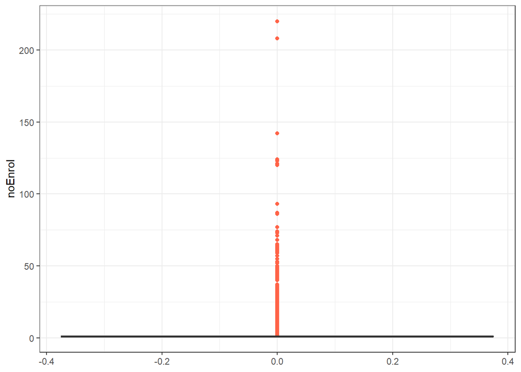

```r
ggplot(enrol) +
  geom_boxplot(aes(y = noEnrol), outlier.colour = "tomato") +
  theme_bw()
```

It seems like our assumption is true. Let’s check how many observations that have *noEnrol* > 0 and what is the proportion of this compared to the entired observation:

```r
nrow(subset(enrol, noEnrol != 1))
```

```
## [1] 7188
```

```r
nrow(subset(enrol, noEnrol != 1))/nrow(enrol)
```

```
## [1] 0.05573519
```

Since the proportion of outliers is essentially low, we can exclude these outliers from the data frame.

```r
enrol2 <- subset(enrol, noEnrol == 1)
summary(enrol2$noEnrol)
```

```
##    Min. 1st Qu.  Median    Mean 3rd Qu.    Max.
##       1       1       1       1       1       1
```

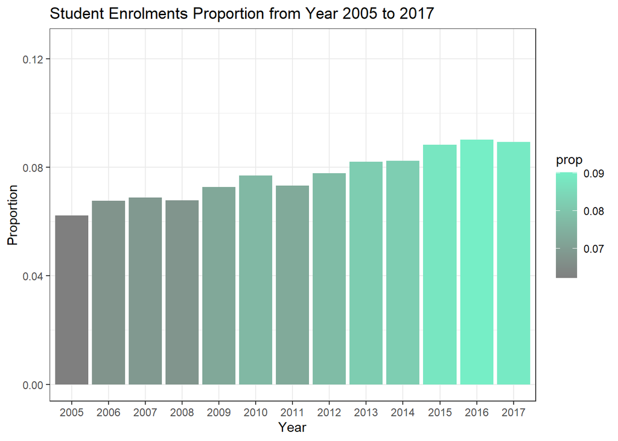

```r
ggplot(enrol2) +
  geom_bar(aes(x = Year, y = ..prop.., group = 1, fill = ..prop..)) +
  theme_bw() +
  labs(x = "Year", y = "Proportion",
       title = "Student Enrolments Proportion from Year 2005 to 2017") +
  coord_cartesian(ylim = c(0, 0.125)) +
  scale_fill_gradient(low = "grey50", high = "aquamarine2")
```

An interpretation of the above bar chart is that the proportion of student enrolments is gradually increasing over the decade and reaching the highest proportion in 2016.

## The `head()` command

Let’s look at the first 10 observations of the data by using function `head()`.

```r
head(enrol2, 10)
```

|  | X | Year | state | institution_code | Institution | Institution_Type | broad_course_type | course_type | gender | age | Commencing | overseas | indigenous | attendance_type | attendance_mode | broad_foe | Narrow_FOE | perm_home_post | perm_home_country | disability | basis_for_admission | special_course | country_of_birth | highest_ed_attainment | perm_home_res | supp_broad_foe | SES | X_Field_of_Education | X_Supp_field_of_education | … |
| --- | --- | --- | --- | --- | --- | --- | --- | --- | --- | --- | --- | --- | --- | --- | --- | --- | --- | --- | --- | --- | --- | --- | --- | --- | --- | --- | --- | --- | --- | --- |
| 1 | 1 | 2017 | ACT | 3033 | The Australian National University | Go8 University | Undergraduate | Bachelor's Honours | Females | 19 | Non-commencing | Domestic | Not Indigenous | Full-time | Internal | Society And Culture | Law | A2558 | NA | Disability | Not a commencing student | Not a course of special interest | Australia | Not commencing students | Australia | Creative Arts | Not low SES | 90900 | 100300 | … |
| 2 | 2 | 2008 | ACT | 3033 | The Australian National University | Go8 University | Higher Degree Research | Master's by Research | Males | 27 | Non-commencing | Overseas | Not Indigenous | Full-time | Internal | Natural And Physical S | Other Natural And Physical Sciences | X5202 | Indonesia | No-Disability | Higher education course (Australian or overseas equivalent; complete or incomplete) | Not a course of special interest | Indonesia | Overseas student | NA | NA | Not Low SES | 19999 | 0 | … |
| 3 | 3 | 2009 | ACT | 3033 | The Australian National University | Go8 University | Undergraduate | Bachelor's Pass | Males | 17 | Commencing | Overseas | Not Indigenous | Full-time | Internal | Management And Commerc | Business And Management | X6102 | Hong Kong (SAR of China) | No-Disability | VET award course other than a secondary education course (Australian or overseas equivalent; complete or incomplete) | Not a course of special interest | China (excludes SARs and Taiwan Province) | Overseas student | NA | NA | Not Low SES | 80301 | 0 | … |
| 4 | 4 | 2005 | ACT | 3033 | The Australian National University | Go8 University | Postgraduate Coursework | Master's by Coursework | Males | 26 | Commencing | Domestic | Not Indigenous | Full-time | Internal | Society And Culture | Economics And Econometrics | A4109 | NA | No-Disability | Higher education course (Australian or overseas equivalent; complete or incomplete) | Not a course of special interest | Australia | Completed Bachelor course | NA | NA | Not Low SES | 91901 | 0 | … |
| 5 | 5 | 2007 | ACT | 3033 | The Australian National University | Go8 University | Undergraduate | Non-Award Course | Females | 26 | Commencing | Domestic | Not Indigenous | Part-time | Internal | NA | NA | A5015 | NA | No-Disability | Higher education course (Australian or overseas equivalent; complete or incomplete) | Not a course of special interest | No Information | No prior educational attainment | NA | NA | Not Low SES | 0 | 0 | … |
| 6 | 6 | 2008 | ACT | 3033 | The Australian National University | Go8 University | Undergraduate | Bachelor's Pass | Males | 17 | Commencing | Domestic | Not Indigenous | Full-time | Internal | Society And Culture | Political Science And Policy Studies | A2021 | NA | No-Disability | Secondary education (Australian or overseas equivalent) | Not a course of special interest | Australia | Completed secondary education | NA | NA | Not Low SES | 90101 | 0 | … |
| 7 | 7 | 2008 | ACT | 3033 | The Australian National University | Go8 University | Undergraduate | Diploma (AQF) | Males | 40 to 49 | Non-commencing | Domestic | Not Indigenous | Part-time | Internal | Society And Culture | Language And Literature | A2602 | NA | Disability | Not stated | Not a course of special interest | Australia | Not commencing students | NA | NA | Not Low SES | 91599 | 0 | … |
| 8 | 8 | 2013 | ACT | 3033 | The Australian National University | Go8 University | Undergraduate | Bachelor's Graduate Entry | Males | 25 | Non-commencing | Domestic | Not Indigenous | Full-time | Internal | Health | Medical Studies | X1201 | New Zealand | No-Disability | Not stated | A course leading to provisional registration as a medical practitioner | Korea, Republic of (South) | Not commencing students | New Zealand | Non-award courses | Not Low SES | 60101 | 0 | … |
| 9 | 9 | 2014 | ACT | 3033 | The Australian National University | Go8 University | Undergraduate | Bachelor's Pass | Males | 22 | Non-commencing | Domestic | Not Indigenous | Full-time | Internal | Society And Culture | Other Society And Culture | A2795 | NA | no disability | Not a commencing student | Not a course of special interest | Australia | Not commencing students | Australia | Society and Cultu | Not low SES | 99999 | 90999 | … |
| 10 | 10 | 2007 | ACT | 3033 | The Australian National University | Go8 University | Higher Degree Research | Doctorate by Research | Females | 30 to 39 | Non-commencing | Domestic | Not Indigenous | Full-time | Internal | Natural And Physical S | Other Natural And Physical Sciences | A2902 | NA | Disability | Higher education course (Australian or overseas equivalent; complete or incomplete) | Not a course of special interest | Australia | Completed Bachelor course | NA | NA | Not Low SES | 19901 | 0 | … |

The `head()` function helps us obtain a general idea of how the data frame looks like in tabular format. Here, we can see that some of the columns have missing values, some are redundant, not informative or possibly reduntdant with one another. Let’s observe these attributes in more details:

### Institution & institution_code

```r
summary(enrol2[,c("Institution", "institution_code")])
```

```
##  Institution        institution_code
##  Length:121779      3035   : 6203
##  Class :character   3013   : 5264
##  Mode  :character   3036   : 5006
##                     3042   : 4948
##                     3030   : 4859
##                     3019   : 4840
##                     (Other):90659
```

```r
str(enrol2[,c("Institution", "institution_code")])
```

```
## 'data.frame':    121779 obs. of  2 variables:
##  $ Institution     : chr  "The Australian National University" "The Australian National University" "The Australian National University" "The Australian National University" ...
##  $ institution_code: Factor w/ 44 levels "1019","1034",..: 34 34 34 34 34 34 34 34 34 34 ...
```

The summary output above tells us that there is no missing values in both columns, and the number of observations belong to each institution seems to match with the number of observations belong to one of the institution code except for the University of Sydney. Hence, it is possible that each of the institution code does not uniquely represent the institution. Moreover, the structure output tells us that the factor levels of both columns do not match, thus supporting the summary output that some of the institutions may have more than one code. We can check whether which institution has duplicate codes programmatically using `count()` and `duplicated()`.

```r
by_institution <- enrol2 %>%
  count(Institution, institution_code)
dup_ins <- unlist(by_institution[duplicated(by_institution$Institution), "Institution"])
subset(by_institution, Institution %in% dup_ins)
```

|  | Institution | institution_code | n |
| --- | --- | --- | --- |
| 28 | The University of Sydney | 3015 | 963 |
| 29 | The University of Sydney | 3040 | 4703 |
| 32 | University of New England | 3011 | 836 |
| 33 | University of New England | 3039 | 1601 |
| 39 | University of Technology, Sydney | 2123 | 1024 |
| 40 | University of Technology, Sydney | 3016 | 2797 |

```r
rm(by_institution, dup_ins)
```

There are 3 institutions, *The University of Sydney*, *University of New England* and *University of Technology, Sydney* that have 2 corresponding institution codes. However, since we cannot check whether these codes are the true representatives of the institutions, it is better to exclude the institution_code column from our investigation. Now, with the use of `geom_bar()` we can visualise the proportion of students in each institutions.

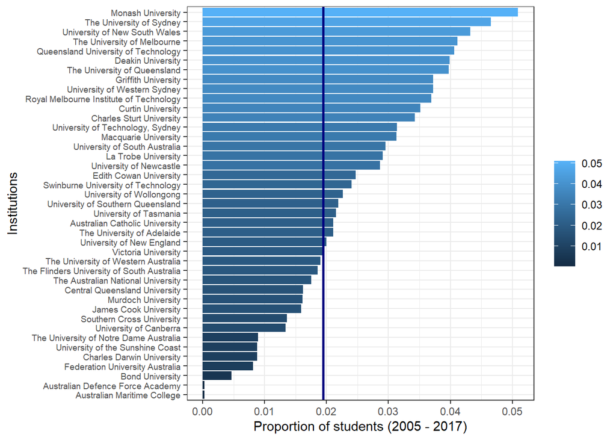

```r
ggplot(enrol2) +
  geom_bar(aes(x = reorder(Institution, Institution, length),
               y = ..prop.., group = 1, fill = ..prop..)) +
  scale_fill_gradient() +
  theme(legend.position = "none") +
  geom_hline(yintercept = 2508/128967, colour = "navy", size = 1) +
  theme_bw() +
  coord_flip() +
  labs(y = "Proportion of students (2005 - 2017)",
       x = "Institutions", fill = "") +
  theme(axis.text.y = element_text(size = rel(0.8),
                                   vjust = 0.5, hjust = 1))
```

Above is the bar chart representing the proportion students enrolments of each institutions from year 2005 to 2017 inclusive. The reason why I chose to plot proportion instead of count is because we essentially took only 1% of the real population data, thus interpretting on count would be inappropriate. Here, the bar chart tells us that *Monash University*, *the University of Sydney* and *University of New South Wales* are the top 3 most popular institutions in Australia with respect to the proportion of student enrolments from 2005 to 2017, while *Bond University*, *Australian Defence Force Academy* and *Australian Maritime College* are the bottom 3. In addition, a blue horizontal line represents the proportion of student enrolments of The University of Western Australia, which is in the bottom half of the rest of the institutions.

However, it’s quite suspicious that the *Australian Defence Force Academy* and *Australian Maritime College* held an abnomally low proportion of student enrolments in 13 years combined! Therefore, I then explore the variation of student enrolments with respect to time (Year) using `geom_tile()`.

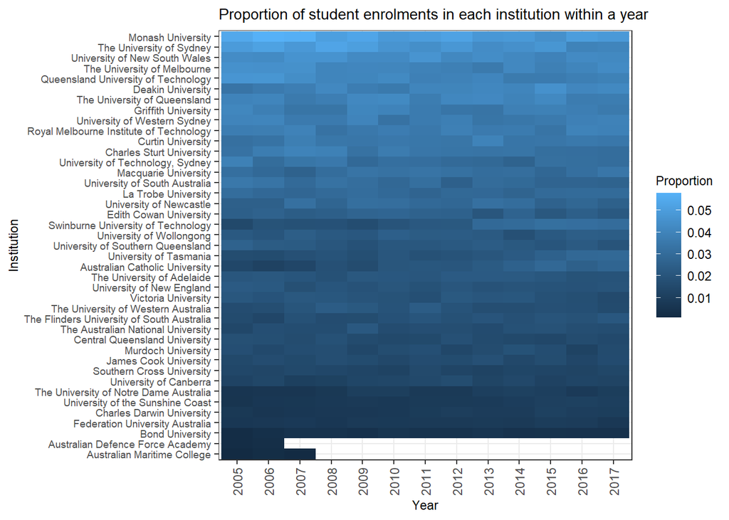

```r
enrol2 %>%
  count(Year, Institution) %>%
  group_by(Year) %>%
  mutate(prop = n / sum(n)) %>%
  ggplot(mapping = aes(x = Year, y = Institution)) +
  geom_tile(mapping = aes(y = reorder(Institution, n),fill = prop)) +
  theme_bw() +
  labs(x = "Year", y = "Institution", fill = "Proportion",
       title = "Proportion of student enrolments in each institution within a year") +
  theme(axis.text.y = element_text(size = rel(0.8), vjust = 0.5, hjust = 1),
        axis.text.x = element_text(angle = 90, vjust = 0.5, hjust = 1),
        title = element_text(size = rel(0.8)))
```

With the tile plot above we can see how some of the institutions are getting more popular (increasing enrolments) or getting less popular (decreasing enrolments) across the decade. For example, Swinburne University of Technology is getting more popular as the colour of the rectangle goes from dark blue (low proportion) in 2005 to almost light blue (high proportion) in 2017. Edith Cowan University, however, tends to be less popular across the decades as the rectangle colour goes from fairly light blue in 2005 to somewhat dark blue in 2017.

Moreover, we notice that the *Australian Defence Force Academy* and the *Australian Maritime College* are actually missing a large portion of data from year 2007 and 2008, repectively. So, it is not fair to say that they are among the least popular institutions compare with others. Therefore it is better to exclude these two institutions from our investigation about institution. Below is the fixed bar chart and tile plot:

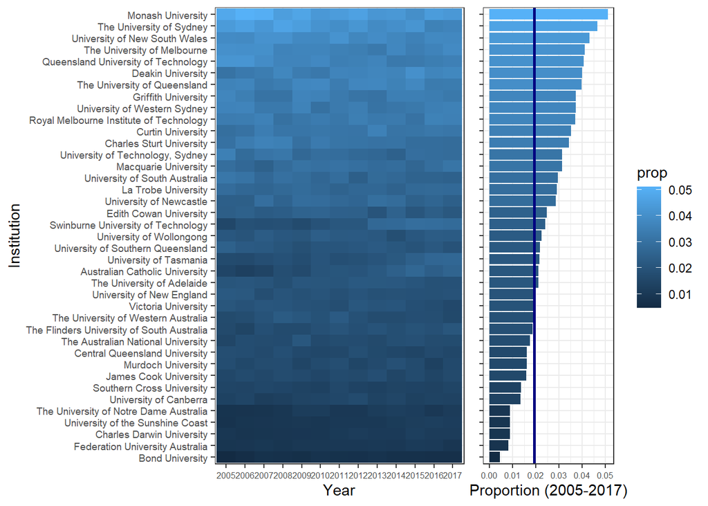

```r
a <- c("Australian Defence Force Academy", "Australian Maritime College")
ins1 <- ggplot(subset(enrol2, !(Institution %in% a))) +
  geom_bar(aes(x = reorder(Institution, Institution, length),
               y = ..prop.., group = 1, fill = ..prop..)) +
  scale_fill_gradient() +
  theme(legend.position = "none") +
  geom_hline(yintercept = 2508/128967, colour = "navy", size = 1) +
  theme_bw() +
  coord_flip() +
  labs(y = "Proportion (2005-2017)") +
  theme(axis.text.y = element_blank(),
        axis.title.y = element_blank(),
        axis.text.x = element_text(size = rel(0.7)))

ins2 <- subset(enrol2, !(Institution %in% a))  %>%
  count(Year, Institution) %>%
  group_by(Year) %>%
  mutate(prop = n / sum(n)) %>%
  ggplot(mapping = aes(x = Year, y = Institution)) +
  geom_tile(mapping = aes(y = reorder(Institution, n), fill = prop)) +
  theme_bw() +
  labs(x = "Year") +
  theme(axis.text.y = element_text(size = rel(0.8),
                                   vjust = 0.5,
                                   hjust = 1),
        axis.text.x = element_text(size = rel(0.7)),
        legend.position = "none")

grid.arrange(ins2, ins1, ncol = 2, widths = c(2,1))
```

```r
rm(a, ins1, ins2)
```

### Age

```r
enrol2 %>%
  count(age)
```

| age | n |
| --- | --- |
| 16 and under | 249 |
| 17 | 5309 |
| 18 | 11431 |
| 19 | 12240 |
| 20 | 11682 |
| 21 | 10479 |
| 22 | 8458 |
| 23 | 7007 |
| 24 | 5705 |
| 25 | 4914 |

[output cut: 8 more lines]

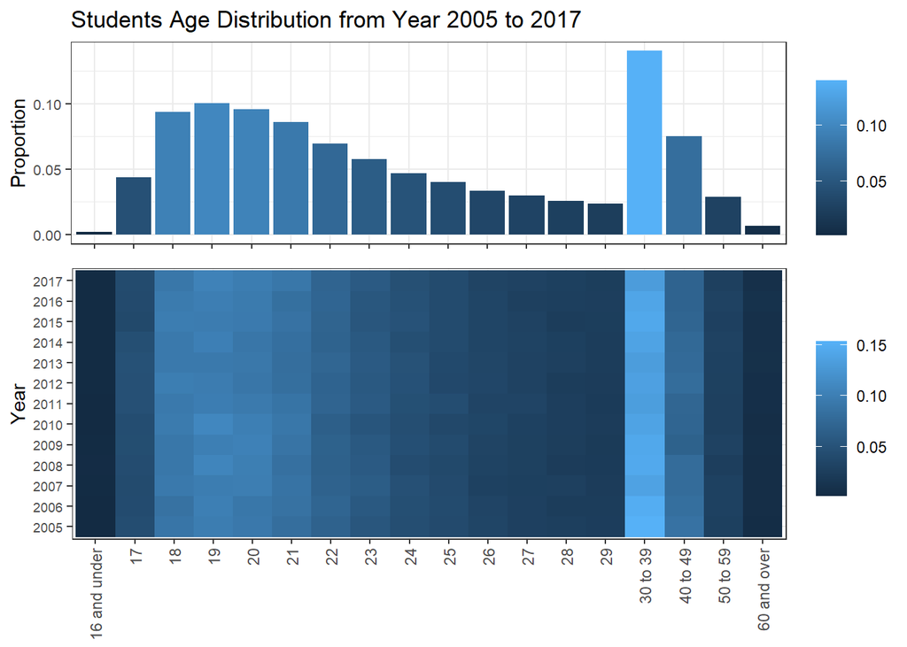

```r
age1 <- ggplot(enrol2, aes(x = age)) +
  geom_bar(aes(y = ..prop.., group = 1, fill = ..prop..)) +
  scale_fill_gradient() +
  labs(x = "Age Group", y = "Proportion", fill = "") +
  theme_bw() +
  labs(title = "Students Age Distribution from Year 2005 to 2017") +
  theme(axis.text.x = element_blank(),
        axis.title.x = element_blank(),
        axis.text.y = element_text(size = rel(0.9)))

age2 <- enrol2 %>%
  count(Year, age) %>%
  group_by(Year) %>%
  mutate(prop = n / sum(n)) %>%
  ggplot(mapping = aes(y = age, x = Year)) +
  geom_tile(mapping = aes(fill = prop)) +
  theme_bw() +
  labs(y = "Age Group", x = "Year", fill = "") +
  theme(axis.text.x = element_text(angle = 90,
                                   vjust = 0.5,
                                   hjust = 1),
        axis.title.x = element_blank(),
        axis.text.y = element_text(size = rel(0.8))) +
  coord_flip()

grid.arrange(age1, age2, nrow = 2, heights = c(2,3))
```

```r
rm(age1, age2)
```

Since both charts share the same x-axis tick values, I have put together the bar chart and the tile plot of age distribution from year 2005 to 2017 using `grid.arrange()`.

From the bar chart, the *age* column has ages 17 to 29 entered as integer, while other uncommon ages (younger than 16-year-old and older than 30-year-old) are grouped . Normally, we would expect a right-skewed age distribution at any institutions because people age around 17 to 29 tend to study at universities more than any other age groups. However, having age 30 and above grouped for every ten years made the age distribution looks like a **bimodal distribution**. To check whether this is also the case for year 2005 to 2017, a `geom_tile` function was used.

From the tile plot above where light blue colour indicates a relatively high proportion and the dark blue indicates the opposite, we can conclude that the age distribution in institutions look pretty similar across the decade. Having light blue colour flock around age `19` and `30 to 39` assure us that the age distribution is indeed a bimodal distribution.

The way of catagorizing the age variable like this is fairly rational in my opinion, as we would generally want to investigate the behaviour of young adults and adults in the institutions seperately. This is because these two groups of people tends to study in the different course types, e.g. young students tend to study undergraduate degree while older students tend to study postgraduate degree. Hence, I will classify the age attribute further into two sub groups, the young adult with age 29 and below and the adults with age 30 and above (having age 30 as a cut-off).

```r
yadults <- c("16 and under", "17", "18", "19", "20", "21",
             "22", "23", "24", "25", "26", "27", "28", "29")
enrol2$Age_Group <- ifelse(enrol2$age %in% yadults, "Young Adults", "Adults")
enrol2$Age_Group <- as.factor(enrol2$Age_Group)
summary(enrol2$Age_Group)
```

```
##       Adults Young Adults
##        30587        91192
```

```r
rm(yadults)
```

Now that we have divided the original age column into two categories, the distribution of the two groups can be visualised below. Again, we can see the right-skewed distribution from the *Young Adults* group while *Adults* group experiencing a steeply decreasing trend.

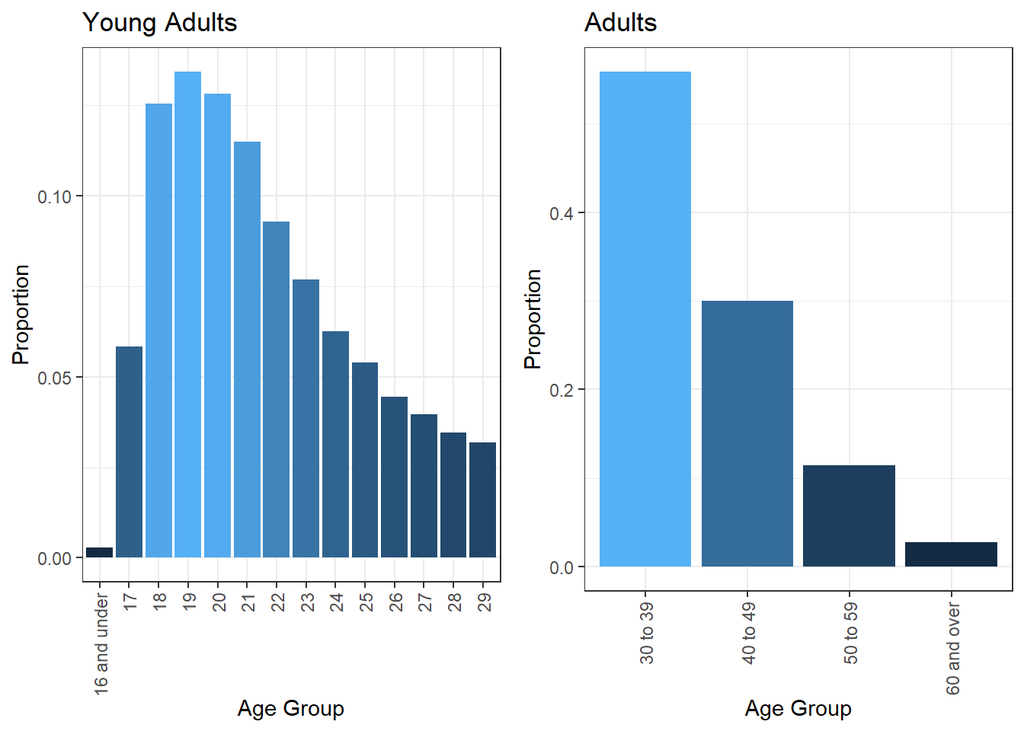

```r
age1 <- ggplot(subset(enrol2, Age_Group == "Young Adults")) +
  geom_bar(aes(x = age, y = ..prop.., group = 1, fill = ..prop..)) +
  scale_fill_gradient() +
  theme_bw() +
  labs(x = "Age Group", y = "Proportion", title = "Young Adults") +
  theme(axis.text.x = element_text(angle = 90, vjust = 0.5, hjust = 1),
        legend.position = "none")


age2 <- ggplot(subset(enrol2, Age_Group == "Adults")) +
  geom_bar(aes(x = age, y = ..prop.., group = 1, fill = ..prop..)) +
  scale_fill_gradient() +
  theme_bw() +
  labs(x = "Age Group", y = "Proportion", title = "Adults") +
  theme(axis.text.x = element_text(angle = 90, vjust = 0.5, hjust = 1),
        legend.position = "none")

grid.arrange(age1, age2, ncol = 2)
```

```r
rm(age1, age2)
```

### broad_foe, Narrow_FOE and X_Field_of_Education

The same observation is missing both **broad_foe** and **Narrow_FOE** fields. According to Australian Government Department of Education, broad_foe and Narrow_FOE columns are derived from **X_Field_of_Education** column, hence redundancy. Below is the code to check whether NAs values in broad_foe and Narrow_FOE match the value of 0 in X_Field_of_Education:

```r
# Check for redundancy between X_Field_of_Education and broad_foe
identical(is.na(enrol2$broad_foe), enrol2$X_Field_of_Education == 0) &
  identical(!is.na(enrol2$broad_foe), enrol2$X_Field_of_Education != 0)
```

```
## [1] TRUE
```

```r
# Check for redundancy between X_Field_of_Education and Narrow_FOE
identical(is.na(enrol2$Narrow_FOE), enrol2$X_Field_of_Education == 0) &
  identical(!is.na(enrol2$Narrow_FOE), enrol2$X_Field_of_Education != 0)
```

```
## [1] TRUE
```

Hence, it is safe to use the **broad_foe** and the **Narrow_FOE** columns as substitutes of the **X_Field_of_Education** column. Now, with the `summary()` function, we can check how many NAs these two attributes have.

```r
summary(enrol2[c("broad_foe", "Narrow_FOE")])
```

```
##   broad_foe          Narrow_FOE
##  Length:121779      Length:121779
##  Class :character   Class :character
##  Mode  :character   Mode  :character
```

Since *broad_foe* and *Narrow_FOE* columns are both missing exactly 1326 values, let’s check whether these missing values are from the same observations.

```r
identical(which(is.na(enrol2$broad_foe)), which(is.na(enrol2$Narrow_FOE)))
```

```
## [1] TRUE
```

```r
#Or
summary(enrol2[is.na(enrol2$Narrow_FOE), "broad_foe"])
```

```
##    Length     Class      Mode
##      1326 character character
```

```r
enrol2 <- subset(enrol2,!is.na(enrol2$broad_foe))
summary(enrol2$broad_foe)
```

```
##    Length     Class      Mode
##    120453 character character
```

```r
sum(is.na(enrol2$Narrow_FOE))
```

```
## [1] 0
```

The outputs above tells us that there is no missing values in both broad_foe and Narrow_FOE columns. Once we omit the row with missing values, we can use visualisation to study the attribute further.

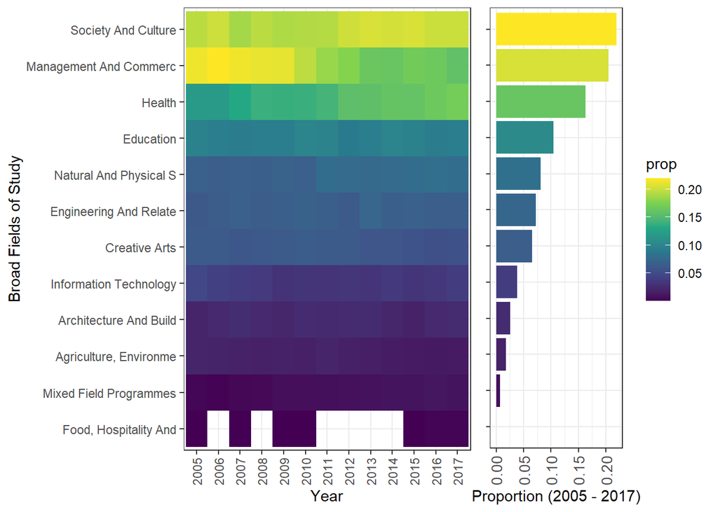

```r
bfoe1 <- ggplot(enrol2, aes(x = broad_foe)) +
  geom_bar(aes(x = reorder(broad_foe, broad_foe, length),
                         y = ..prop.., group = 1,
               fill = ..prop..)) +
  coord_flip() +
  theme_bw() +
  theme(axis.title.y = element_blank(),
        axis.text.y = element_blank(),
        axis.text.x = element_text(size = rel(1.2),
                                   angle = 90,
                                   vjust = 0.5,
                                   hjust = 1)) +
  labs(y = "Proportion (2005 - 2017)",
       x = "Broad Fields of Study") +
  scale_fill_viridis_c()

bfoe2 <- enrol2  %>%
  count(Year, broad_foe) %>%
  group_by(Year) %>%
  mutate(prop = n / sum(n)) %>%
  ggplot(mapping = aes(x = Year, y = broad_foe)) +
  geom_tile(mapping = aes(y = reorder(broad_foe, n), fill = prop)) +
  theme_bw() +
  labs(x = "Year", y = "Broad Fields of Study") +
  theme(axis.text.x = element_text(angle = 90,
                                   vjust = 0.5,
                                   hjust = 1),
        legend.position = "none") +
  scale_fill_viridis_c()

grid.arrange(bfoe2, bfoe1, ncol = 2, widths = c(2,1))
```

```r
rm(bfoe1, bfoe2)
```

The bar chart on the right represents the proportion of student enrolments in each of the broad fields of study from year 2005 to 2017 inclusive. Society & Culture and Management & Commerce are the most popular fields of study with a proportion of around 0.21, while Mixed Field Programs and Food, Hospitality and Personal Services are the least popular.

Now, looking at the narrow fields of study of the top 3 broad fields of study which are *Management & Commerce*, *Society & Culture* and *Health*, we can see that which narrow field of study is the most popular among each broad field of study. The reason why I chose to visualise only the top 3 broad fields of study is to avoid having too many categories in the y-axis which would make the plot unreadable.

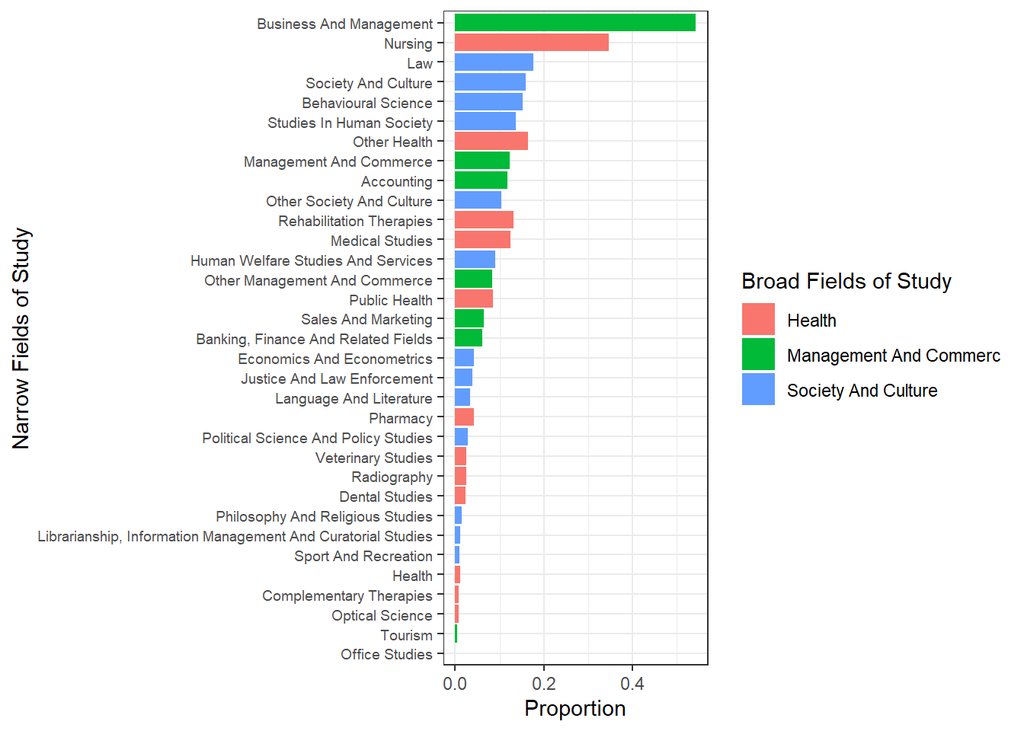

```r
top3_broad_foe <- c("Management And Commerc", "Society And Culture", "Health")
by_top3_foe <- subset(enrol2, broad_foe %in% top3_broad_foe)

ggplot(by_top3_foe, aes(x = Narrow_FOE, group = broad_foe)) +
  geom_bar(aes(x = reorder(Narrow_FOE, Narrow_FOE, length),
              y = ..prop.., group = broad_foe, fill = broad_foe)) +
  coord_flip() +
  theme_bw() +
  labs(y = "Proportion",
       x = "Narrow Fields of Study",
       fill = "Broad Fields of Study") +
  theme(axis.text.y = element_text(size = rel(0.8),
                                   vjust = 0.5,
                                   hjust = 1))
```

```r
rm(by_top3_foe, top3_broad_foe)
```

From the bar chart above, we can conclude that *Business and Management* is the most popular narrow field of study among any other narrow fields and also among the *Management & Commerce* broad field holding the highest proportion of about 0.52.

### perm_home_post, Perm_Home_Postcode_Description & Australian_Region

According to the [Australian Government Department of Education](https://heimshelp.education.gov.au/2015_data_requirements/2015dataelements/320) The **perm_home_post** and **Perm_Home_Postcode_Description** attributes obviously have some connections, where letter ‘X’ and ‘A’ at the begining of perm_home_post field indicates ‘International’ and ‘Australia’, respectively. We can say that The Perm_Home_Postcode_Description is essentially derived from perm_home_post column, and hence redundant. Below is the code chunk to check whether the perm_home_post column and the Perm_Home_Post_Description column connect in any way:

```r
# Extracting the first element of perm_home_post
enrol2$ini_perm_home_post <- substr(enrol2$perm_home_post, 1, 1)
enrol2$ini_perm_home_post <- ifelse(enrol2$ini_perm_home_post == "X", "International",
                                   ifelse(enrol2$ini_perm_home_post == "A", "Australia", "Unknown"))
enrol2$ini_perm_home_post <- as.factor(enrol2$ini_perm_home_post)

# Editing Perm_Home_Postcode_Description
enrol2$PHPD_fixed <- ifelse(enrol2$Perm_Home_Postcode_Description == "International", "International",
                          ifelse(enrol2$Perm_Home_Postcode_Description == "Unknown", "Unknown", "Australia"))
enrol2$PHPD_fixed <- as.factor(enrol2$PHPD_fixed)

# Checking for identical
identical(enrol2$ini_perm_home_post, enrol2$PHPD_fixed)
```

```
## [1] TRUE
```

```r
summary(enrol2[,c("ini_perm_home_post", "PHPD_fixed")])
```

```
##      ini_perm_home_post         PHPD_fixed
##  Australia    :102071   Australia    :102071
##  International: 18280   International: 18280
##  Unknown      :   102   Unknown      :   102
```

```r
enrol2 <- select(enrol2, -c("ini_perm_home_post", "PHPD_fixed"))
```

Hence, we are safe to use the **Perm_Home_Postcode_Description** column in place of the **perm_home_post** column.

It is also a great idea to extract the state in Australia where students’ permanent home address is and see whether it matches with the **Australian_Region** attributes. A code chunk below will extract the last word in string of Perm_Home_Postcode_Description and put it in the new column called **perm_home_state**. The first line of code is adapted from: [Extracy last word in string in R](https://stackoverflow.com/questions/17658216/extract-last-word-in-string-in-r?noredirect=1&lq=1)

```r
enrol2$perm_home_state <- sapply(strsplit(as.vector(enrol2$Perm_Home_Postcode_Description), " "), tail, 1)
enrol2$perm_home_state <- as.factor(enrol2$perm_home_state)
summary(enrol2$perm_home_state)
```

```
##             ?           ACT International           NSW            NT
##             2          2883         18280         33565           872
##           QLD            SA           TAS       Unknown           VIC
##         19664          7287          2066           102         25312
##            WA
##         10420
```

From the summary output, there are 2 ‘?’ observations which are incomprehensible. The next chunk of code will rename this category to ‘Unknown’ and then the new summary of perm_home_state:

```r
enrol2$perm_home_state <- ifelse(enrol2$perm_home_state == "?",
                                      "Unknown",
                                      as.character(enrol2$perm_home_state))
enrol2$perm_home_state <- as.factor(enrol2$perm_home_state)
summary(enrol2$perm_home_state)
```

```
##           ACT International           NSW            NT           QLD
##          2883         18280         33565           872         19664
##            SA           TAS       Unknown           VIC            WA
##          7287          2066           104         25312         10420
```

Now that the attributes is tidy, we will check whether it has a connection with **Australian_Region** Attribute using the function `count()`. (The `summarize(group_by())` will return the same output except that it does not count the number of observations belong to each group.)

```r
enrol2 %>%
  count(perm_home_state, Australian_Region)
```

| perm_home_state | Australian_Region | n |
| --- | --- | --- |
| ACT | Interstate-NSW & ACT | 2883 |
| International | International | 18280 |
| NSW | Interstate-NSW & ACT | 33541 |
| NSW | Interstate-VIC | 24 |
| NT | Interstate-NT | 814 |
| NT | Interstate-QUEENSLAND | 58 |
| QLD | Interstate-QUEENSLAND | 19664 |
| SA | Interstate-SA | 7287 |
| TAS | Interstate-TAS | 2066 |
| Unknown | Interstate-NSW & ACT | 1 |

[output cut: 16 more lines]

```r
#summarize(group_by(enrol2, perm_home_state, Australian_Region))
```

It seems like there is a relationship between these attributes. We can see roughly that the International field and all WA’s regions match. However, they are not entirely redundant with one another from the fact that quite a number of perm_home_state do not match the Australian Region. See below:

```r
state <- enrol2 %>% count(perm_home_state, Australian_Region)
state <- subset(state, perm_home_state == "NSW" & Australian_Region == "Interstate-VIC"|
       perm_home_state == "NT" & Australian_Region == "Interstate-QUEENSLAND" |
       perm_home_state == "Unknown" & Australian_Region == "Interstate-NSW & ACT" |
       perm_home_state == "Unknown" & Australian_Region == "Interstate-QUEENSLAND")
state
```

|  | perm_home_state | Australian_Region | n |
| --- | --- | --- | --- |
| 4 | NSW | Interstate-VIC | 24 |
| 6 | NT | Interstate-QUEENSLAND | 58 |
| 10 | Unknown | Interstate-NSW & ACT | 1 |
| 11 | Unknown | Interstate-QUEENSLAND | 1 |

```r
rm(state)
```

Since the source of Australian_Region attribute is obscure, it is arbitrary to say that we could map the Unknown fields in Perm_Home_Post_Description (perm_home_state) with Australian_Region. Therefore, between **perm_home_post**, **Australian_Region** and **Perm_Home_Postcode_Description**, I decide to exclude the first two attributes from our investigation because of redundancy and unrecognized data source, respectively.

Considering only students who live in Australia only, the pie chart illustrating proportion of students enrolments from each Australia state/territory is shown below. The code in this chunk was adapted from [Order piechart pieces](https://stackoverflow.com/questions/48154472/order-piechart-pieces) from stackoverflow question forum.

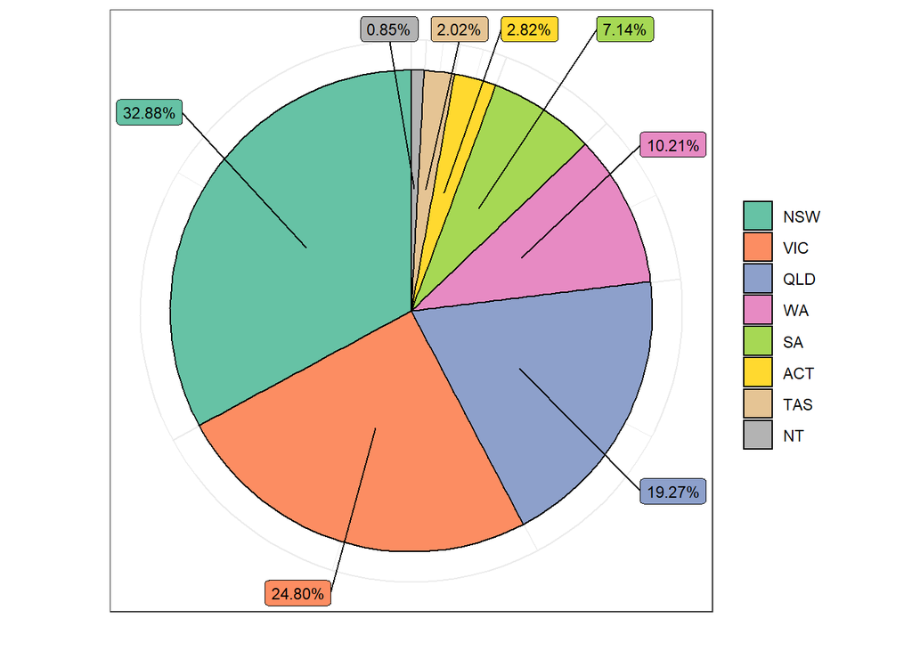

```r
b <- c("Unknown", "International")
home <- subset(enrol2, !(enrol2$perm_home_state %in% b)) %>%
  group_by(perm_home_state) %>%
  summarise(percent = n() / nrow(.) * 100)

home <- home[order(-home$percent),]
home$text <- 100 - (cumsum(home$percent) - home$percent/2)

ggplot(home, aes(x = 1, y = percent,
                 fill = reorder(perm_home_state, -text))) +
  geom_bar(stat = "identity", colour = "black") +
  geom_label_repel(aes(label = percent(percent/100), y = text),
                   size = 3, show.legend = F, nudge_x = 1) +
  scale_y_continuous(breaks = round(cumsum(rev(home$percent)), 1)) +
  coord_polar("y", start = 0) +
  labs(x = "", y = "", fill = "") +
  theme_bw() +
    theme(axis.text.x = element_blank(),
        axis.text.y = element_blank(),
        axis.ticks = element_blank()) +
  scale_fill_brewer(palette = "Set2")
```

From the pie chart, New South Wales posesses the highest proportion of 32.9%, While Northern Territory holds the lowest proportion of 0.9%.

Now let’s explore the relationship between the state/territory of Institution and the state/territory of student permanent home residence to see whether students tends to study at the same state/territory they are living in or not.

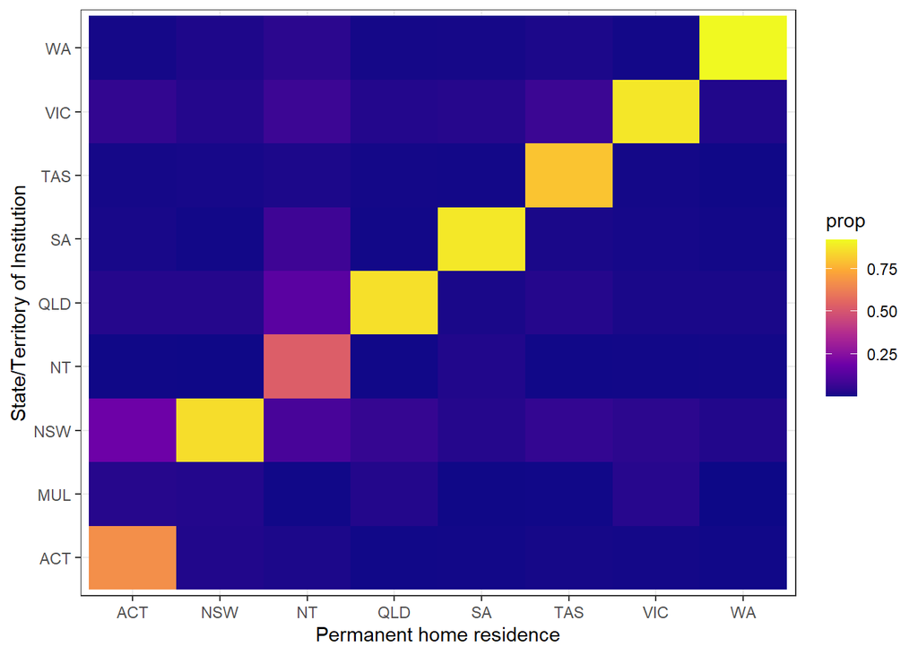

```r
b <- c("Unknown", "International")
subset(enrol2, !(enrol2$perm_home_state %in% b))  %>%
  count(perm_home_state, state) %>%
  group_by(perm_home_state) %>%
  mutate(prop = n / sum(n)) %>%
  ggplot(mapping = aes(y = state, x = perm_home_state)) +
  geom_tile(mapping = aes(fill = prop)) +
  theme_bw() +
  labs(x = "Permanent home residence",
       y = "State/Territory of Institution") +
  scale_fill_viridis_c(option = "plasma")
```

```r
rm(b, home)
```

### disability

The **disability** column has multiple fields inconsistently entered, where we have ‘No-Disability’, ‘no disability’ and ‘No disability’ indicate the same group of students who have no disability. Let’s check this with `summary()` function and then transform the variable if needed:

```r
summary(enrol2$disability)
```

```
##    Length     Class      Mode
##    120453 character character
```

```r
disability <- c("disability", "Disability")
enrol2$disability_fixed <- ifelse((enrol2$disability %in% disability),
                                       "Disability", "No disability")
enrol2$disability_fixed <- as.factor(enrol2$disability_fixed)
summary(enrol2$disability_fixed)
```

```
##    Disability No disability
##          5727        114726
```

```r
rm(disability)
```

When plotting a filled bar chart of disability status over time (Year), the relative frequencies of disability status within a year is shown:

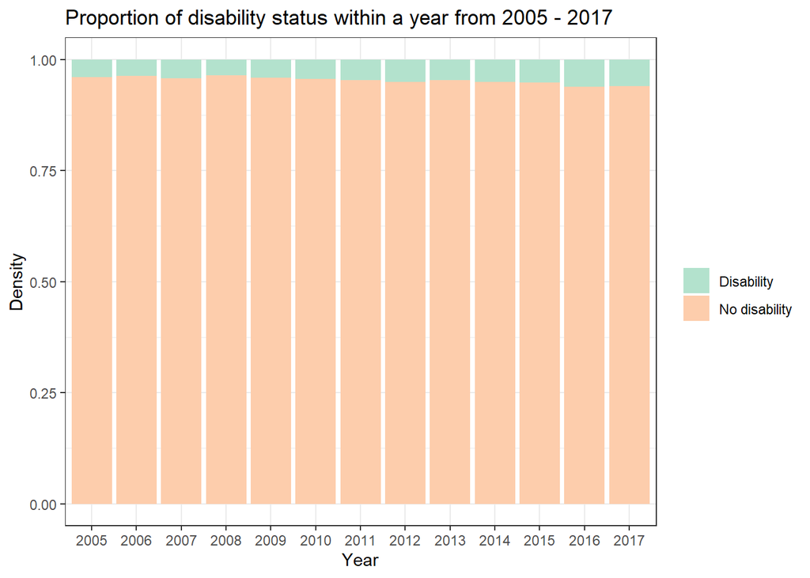

```r
ggplot(enrol2) +
  geom_bar(aes(fill = disability_fixed, x = Year),
           position = "fill") +
  labs(x = "Year", y = "Density", fill = "",
       title = "Proportion of disability status within a year from 2005 - 2017") +
  scale_fill_brewer(palette = "Pastel2") +
  theme_bw()
```

From the chart above, the proportion of students with disability is slightly increasing over time.

### perm_home_res & supp_broad_foe

The same observations are missing both **perm_home_res** and **supp_broad_foe** fields. There is a possibility that there is a relationship between these two columns. let’s check how many NAs are there and whether these missing values are from the same observation:

```r
summary(enrol2[,c("perm_home_res", "supp_broad_foe")])
```

```
##  perm_home_res      supp_broad_foe
##  Length:120453      Length:120453
##  Class :character   Class :character
##  Mode  :character   Mode  :character
```

```r
summary(enrol2[is.na(enrol2$perm_home_res), "supp_broad_foe"])
```

```
##    Length     Class      Mode
##     68250 character character
```

```r
identical(which(is.na(enrol2$perm_home_res)), which(is.na(enrol2$supp_broad_foe)))
```

```
## [1] TRUE
```

```r
enrol2$perm_home_res_fixed <- ifelse(is.na(enrol2$perm_home_res), "Unknown", as.character(enrol2$perm_home_res))
enrol2$perm_home_res_fixed <- as.factor(enrol2$perm_home_res_fixed)
```

```r
enrol2$supp_broad_foe_fixed <- ifelse(is.na(enrol2$supp_broad_foe), "Unknown", as.character(enrol2$supp_broad_foe))
enrol2$supp_broad_foe_fixed <- as.factor(enrol2$supp_broad_foe_fixed)
```

Now the NAs values in perm_home_res and supp_broad_foe are now referred to as Unknown.

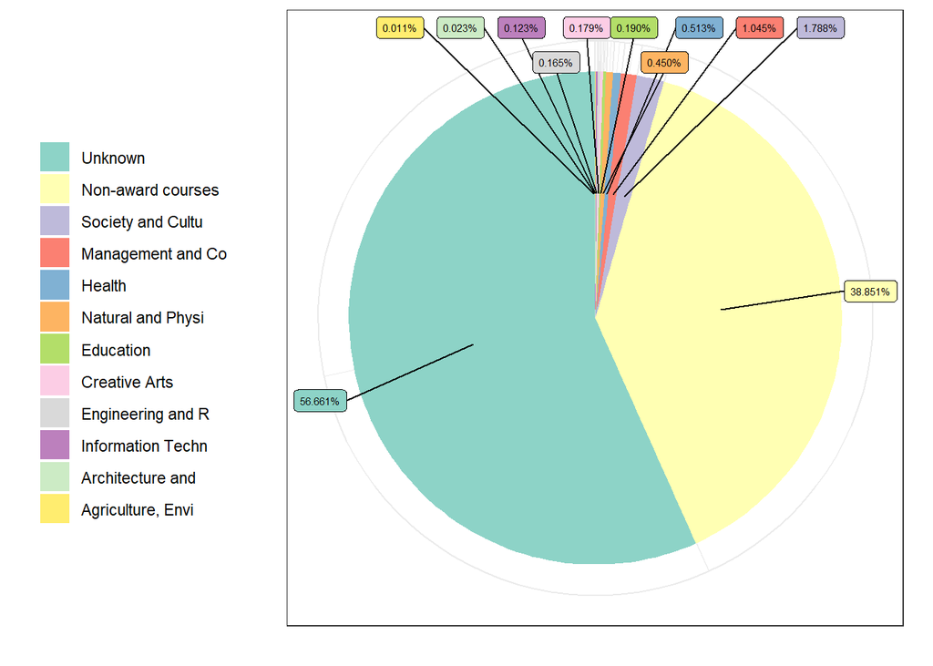

```r
suppbfoe <- enrol2 %>%
  group_by(supp_broad_foe_fixed) %>%
  summarise(percent = n() / nrow(.) * 100)

suppbfoe <- suppbfoe[order(-suppbfoe$percent),]
suppbfoe$text <- 100 - (cumsum(suppbfoe$percent) - suppbfoe$percent/2)

ggplot(suppbfoe, aes(x = 1, y = percent,
                 fill = reorder(supp_broad_foe_fixed, -text))) +
  geom_bar(stat = "identity") +
  geom_label_repel(aes(label = percent(percent/100), y = text),
                   size = 2, show.legend = F, nudge_x = 1) +
  scale_y_continuous(breaks = round(cumsum(rev(suppbfoe$percent)), 1)) +
  coord_polar("y", start = 0) +
  labs(x = "", y = "", fill = "") +
  theme_bw() +
    theme(axis.text.x = element_blank(),
        axis.text.y = element_blank(),
        axis.ticks = element_blank(),
        legend.position = "left") +
  scale_fill_brewer(palette = "Set3")
```

```r
rm(suppbfoe)
```

There are a large proportions of Unknown and Non-award courses, while other supplementary broad fields of study are of a very small proportion.

### X_Supp_field_of_education & supp_broad_foe_fixed

Just like the relationship between **broad_foe**, **Narrow_FOE** and **X_Field_of_Education**, it is pretty likely that **supp_broad_foe** was essentially derived from **X_Supp_field_of_education**. Below is the code to check whether there is any connection:

```r
summarise(group_by(enrol2,X_Supp_field_of_education, supp_broad_foe_fixed))
```

| X_Supp_field_of_education | supp_broad_foe_fixed |
| --- | --- |
| 0 | Non-award courses |
| 0 | Unknown |
| 10000 | Natural and Physi |
| 10000 | Unknown |
| 10100 | Natural and Physi |
| 10100 | Unknown |
| 10101 | Natural and Physi |
| 10101 | Unknown |
| 10199 | Unknown |
| 10300 | Unknown |

[output cut: 329 more lines]

Using `summarise()` and `group_by()` commands on **X_Supp_field_of_education** and **supp_broad_foe_fixed** we can see that for every first digit of X_Supp_field_of_education** seems to refer to one same broad field of study regardless of the Unknown values. Further research on Australia’s fields of education had given me the answer.

There are a total of 12 broad fields of education as stated by the [Australian Government Department of Education](https://heimshelp.education.gov.au/2015_data_requirements/2015dataelements/462). Each 6 digit code represents different field of study. The first two digits refer to the broad field of study, while the rest of the digits refer to the narrow field of study. Hence, we can basically map these two columns together and having all the ‘Unknowns’ in supp_broad_foe_fixed truly fixed!

```r
NatphyS <- c("10000","10100","10101","10199","10300","10301","10303",
             "10500","10501","10503","10599","10700","10701","10703",
             "10705","10707","10709","10711","10713","10799","10900",
             "10901","10903","10905","10907","10909","10911","10913",
             "10915","10999","19900","19901","19903","19905","19907",
             "19909","19999")

CreArts <- c("100000","100100","100101","100103","100105","100199",
             "100300","100301","100303","100305","100307","100309",
             "100399","100500","100501","100503","100505","100599",
             "100700","100701","100703","100705","100707","100799",
             "109900","109999")


enrol2$supp_broad_foe_fixed <- ifelse(enrol2$X_Supp_field_of_education %in% NatphyS, "Natural and Physical Sciences",
                                            ifelse(enrol2$X_Supp_field_of_education %in% CreArts, "Creative Arts",
                                                   ifelse(enrol2$X_Supp_field_of_education == "0", "Non-combined/Non-award/OUA courses",
                                                          as.character(enrol2$X_Supp_field_of_education))))
enrol2$supp_broad_foe_fixed <- as.factor(enrol2$supp_broad_foe_fixed)

enrol2$ini_supp_broad_foe <- substr(enrol2$supp_broad_foe_fixed, 1, 1)
enrol2$ini_supp_broad_foe <- ifelse(enrol2$ini_supp_broad_foe == "2", "Information Technology",
                                               ifelse(enrol2$ini_supp_broad_foe == "3", "Engineering and Related Technologies",
                                                      ifelse(enrol2$ini_supp_broad_foe == "4", "Architecture and Building",
                                                             ifelse(enrol2$ini_supp_broad_foe == "5", "Agriculture, Environmental and Related Studies",
                                                                    ifelse(enrol2$ini_supp_broad_foe == "6", "Health",
                                                                           ifelse(enrol2$ini_supp_broad_foe == "7", "Education",
                                                                                  ifelse(enrol2$ini_supp_broad_foe == "8", "Management and Commerce",
                                                                                         ifelse(enrol2$ini_supp_broad_foe == "9", "Society and Culture",
                                                                                                as.character(enrol2$supp_broad_foe_fixed)))))))))

enrol2$ini_supp_broad_foe <- as.factor(enrol2$ini_supp_broad_foe)
enrol2$supp_broad_foe_fixed <- enrol2$ini_supp_broad_foe
summary(enrol2$supp_broad_foe_fixed)
```

```
## Agriculture, Environmental and Related Studies
##                                             41
##                      Architecture and Building
##                                             68
##                                  Creative Arts
##                                            489
##                                      Education
##                                            618
##           Engineering and Related Technologies
##                                            370
##                                         Health
##                                           1024
##                         Information Technology
##                                            379
##                        Management and Commerce
##                                           2767
##                  Natural and Physical Sciences
##                                           1311
##             Non-combined/Non-award/OUA courses
##                                         108490
##                            Society and Culture
##                                           4896
```

```r
rm(NatphyS, CreArts)
```

Below is the fixed pie chart of supp_broad_foe_fixed from the last section:

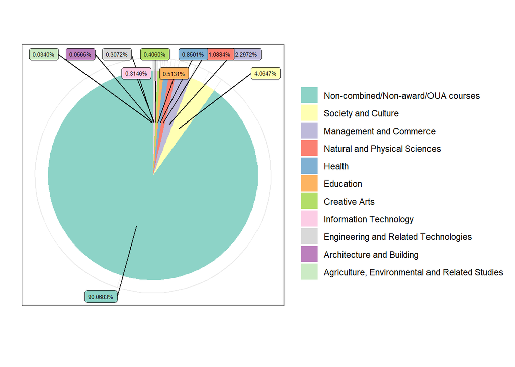

```r
suppbfoe <- enrol2 %>%
  group_by(supp_broad_foe_fixed) %>%
  summarise(percent = n() / nrow(.) * 100)

suppbfoe <- suppbfoe[order(-suppbfoe$percent),]
suppbfoe$text <- 100 - (cumsum(suppbfoe$percent) - suppbfoe$percent/2)

ggplot(suppbfoe, aes(x = 1, y = percent,
                 fill = reorder(supp_broad_foe_fixed, -text))) +
  geom_bar(stat = "identity") +
  geom_label_repel(aes(label = percent(percent/100), y = text),
                   size = 2, show.legend = F, nudge_x = 1) +
  scale_y_continuous(breaks = round(cumsum(rev(suppbfoe$percent)), 1)) +
  coord_polar("y", start = 0) +
  labs(x = "", y = "", fill = "") +
  theme_bw() +
    theme(axis.text.x = element_blank(),
        axis.text.y = element_blank(),
        axis.ticks = element_blank()) +
  scale_fill_brewer(palette = "Set3")
```

```r
rm(suppbfoe)
```

There is an excessively large proportion of student enrolments in a not combined course or non-award course or OUA unit. This is not surprising as usually most of the courses available in the institutions are not combined courses (courses which lead to a single combined award or more than one award). Only a few courses such as BA/DipEd, BA/LLb or BEng are offered as combined courses. Also, if the student did enrol in a course, unit or program which is not a part of the primary course of study, then the enrolment basis is non-award (Australian Government Department of Education, n.d.).

### course_name, nesb & campus_country

```r
summary(enrol2[,c("course_name", "nesb", "campus_country")])
```

```
##  course_name            nesb           campus_country
##  Length:120453      Length:120453      Length:120453
##  Class :character   Class :character   Class :character
##  Mode  :character   Mode  :character   Mode  :character
```

```r
# Checking course_name and nesb
summary(enrol2[is.na(enrol2$course_name), "nesb"])
```

```
##    Length     Class      Mode
##     88099 character character
```

```r
identical(which(is.na(enrol2$course_name)), which(is.na(enrol2$nesb)))
```

```
## [1] TRUE
```

```r
# Checking campus_country and nesb
summary(enrol2[is.na(enrol2$campus_country), "nesb"])
```

```
##    Length     Class      Mode
##     88099 character character
```

```r
identical(which(is.na(enrol2$campus_country)), which(is.na(enrol2$nesb)))
```

```
## [1] TRUE
```

Again, since the missing values proprtion is quite big, we rename NAs to Unknown.

```r
enrol2$course_name_fixed <- ifelse(is.na(enrol2$course_name), "Unknown", as.character(enrol2$course_name))
enrol2$course_name_fixed <- as.factor(enrol2$course_name_fixed)

enrol2$nesb_fixed <- ifelse(is.na(enrol2$nesb), "Unknown", as.character(enrol2$nesb))
enrol2$nesb_fixed <- as.factor(enrol2$nesb_fixed)

enrol2$campus_country_fixed <- ifelse(is.na(enrol2$campus_country), "Unknown", as.character(enrol2$campus_country))
enrol2$campus_country_fixed <- as.factor(enrol2$campus_country_fixed)

summary(enrol2[,c("course_name_fixed", "nesb_fixed", "campus_country_fixed")])
```

```
##             course_name_fixed                           nesb_fixed
##  Unknown             :88099   English Speaking Background    :28633
##  Bachelor of Arts    :  816   Non-English Speaking Background: 3721
##  Bachelor of Nursing :  814   Unknown                        :88099
##  Bachelor of Science :  724
##  Bachelor of Business:  694
##  Bachelor of Commerce:  654
##  (Other)             :28652
##                                      campus_country_fixed
##  Unknown                                       :88099
##  A3010_Uni of Melbourne, Parkville             : 1222
##  A3000_Melbourne                               : 1189
##  A2052_University Of New South Wales, Kensingto: 1181
##  A2006_Sydney University                       : 1149
##  A2007_Broadway                                : 1147
##  (Other)                                       :26466
```

## Dropping unwanted columns

| Attributes | Reason |
| --- | --- |
| X | Not informative |
| institution_code | Redundant with Institution |
| disability | Using disability_fixed instead |
| perm_home_post | Redundant with Perm_Home_Post_Description |
| perm_home_res | Using perm_home_res_fixed instead |
| supp_broad_foe | Using supp_broad_foe_fixed instead |
| X_Field_of_education | Redundant with broad_foe |
| X_Supp_field_of_Education | Redundant with supp_broad_foe_fixed |
| course_name | Using course_name_fixed instead |
| nesb | Using nesb_fixed instead |
| campus_country | Using campus_country_fixed instead |
| noEnrol | All fields now equal 1 |
| Australian_Region | Redundant with Perm_Home_Postcode_Description |
| id | Not informative |
| updatewho | Not informative |
| updatewhen | Not informative |

```r
enrol2<- subset(enrol2, select = -c(X,
                                   institution_code,
                                   disability,
                                   perm_home_post,
                                   perm_home_res,
                                   supp_broad_foe,
                                   X_Field_of_Education,
                                   X_Supp_field_of_education,
                                   course_name,
                                   nesb,
                                   campus_country,
                                   noEnrol,
                                   Australian_Region,
                                   id,
                                   updatewho,
                                   updatewhen))
```

## The `summary()` command

```r
summary(enrol2)
```

```
##       Year          state           Institution        Institution_Type
##  2016   :10898   Length:120453      Length:120453      Length:120453
##  2017   :10792   Class :character   Class :character   Class :character
##  2015   :10664   Mode  :character   Mode  :character   Mode  :character
##  2014   : 9944
##  2013   : 9905
##  2012   : 9390
##  (Other):58860
##  broad_course_type  course_type           gender              age
##  Length:120453      Length:120453      Length:120453      Length:120453
##  Class :character   Class :character   Class :character   Class :character
##  Mode  :character   Mode  :character   Mode  :character   Mode  :character
##
##
##
##
##   Commencing          overseas          indigenous        attendance_type
##  Length:120453      Length:120453      Length:120453      Length:120453
##  Class :character   Class :character   Class :character   Class :character
##  Mode  :character   Mode  :character   Mode  :character   Mode  :character
##
##
##
##
##  attendance_mode     broad_foe          Narrow_FOE        perm_home_country
##  Length:120453      Length:120453      Length:120453      Length:120453
##  Class :character   Class :character   Class :character   Class :character
##  Mode  :character   Mode  :character   Mode  :character   Mode  :character
##
##
##
##
##  basis_for_admission special_course     country_of_birth
##  Length:120453       Length:120453      Length:120453
##  Class :character    Class :character   Class :character
##  Mode  :character    Mode  :character   Mode  :character
##
##
##
##
```

[output cut: 57 more lines]

```
##  English Speaking Background    :28633
##  Non-English Speaking Background: 3721
##  Unknown                        :88099
##
##
##
##
##                                      campus_country_fixed
##  Unknown                                       :88099
##  A3010_Uni of Melbourne, Parkville             : 1222
##  A3000_Melbourne                               : 1189
##  A2052_University Of New South Wales, Kensingto: 1181
##  A2006_Sydney University                       : 1149
##  A2007_Broadway                                : 1147
##  (Other)                                       :26466
```

The data frame looks partially clean, except there are a lot of missing value in **perm_home_country**, **atar**, **mceetya_regional_remote_count**, **asgs_regional_remote_count**, **onshore_indicator**, **regionalremote_value** and **Region** attributes. Moreover, SES values ware inconsistently entered.

### perm_home_country

Firstly, let’s fix the missing values in perm_home_country column by renaming it to Unknown.

```r
enrol2$perm_home_country_fixed <- ifelse(is.na(enrol2$perm_home_country), "Unknown",
                                         as.character(enrol2$perm_home_country))
enrol2$perm_home_country_fixed <- as.factor(enrol2$perm_home_country_fixed)
summary(enrol2$perm_home_country_fixed)
```

```
##                                   Unknown
##                                    102310
## China (Excludes SARs and Taiwan Province)
##                                      2813
##                                 Singapore
##                                      1387
##                                  Malaysia
##                                      1371
##                                     India
##                                      1345
##                  Hong Kong (SAR of China)
##                                      1083
##                                  Viet Nam
##                                       746
##                                 Indonesia
##                                       743
##                Korea, Republic of (South)
##                                       531
##                                 Sri Lanka
##                                       406
##                                  Thailand
##                                       392
##                              Saudi Arabia
##                                       364
##                  United States of America
##                                       361
##                                    Canada
##                                       315
##                                    Taiwan
##                                       309
##                                  Pakistan
##                                       303
##                                     Nepal
##                                       301
##                      United Arab Emirates
##                                       295
##                                Bangladesh
##                                       288
##                               New Zealand
##                                       279
```

[output cut: 145 more lines]

```
##                                        11
##                                  Scotland
##                                        11
##                                  Portugal
##                                        10
##                                   Reunion
##                                         9
##                                Seychelles
##                                         9
##                                 Swaziland
##                                         9
##                                Uzbekistan
##                                         9
##                                   (Other)
##                                       212
```

### Student’s Address and Region

So far, we have a few columns that possibly refer to same information, student’s address. These columns are Perm_Home_Postcode_Description, perm_home_state (extracted state from Perm_Home_Postcode_Description), perm_home_res_fixed and perm_home_country_fixed. It is obvious that perm_home_res_fixed and perm_home_country_fixed attributes focus on the international students side as they have all countries specified separately, while the Perm_Home_Postcode_Description and perm_home_state atrributes focus on the Australian side as they have city and state of Australia specified separately while other countries were marked as International.

```r
summary(enrol2[,c("Perm_Home_Postcode_Description",
                  "perm_home_state",
                  "perm_home_res_fixed",
                  "perm_home_country_fixed")])
```

```
##  Perm_Home_Postcode_Description      perm_home_state
##  Length:120453                  NSW          :33565
##  Class :character               VIC          :25312
##  Mode  :character               QLD          :19664
##                                 International:18280
##                                 WA           :10420
##                                 SA           : 7287
##                                 (Other)      : 5925
##                                 perm_home_res_fixed
##  Unknown                                  :68250
##  Australia                                :44719
##  China (excludes SARs and Taiwan Province): 1238
##  India                                    :  634
##  Singapore                                :  494
##  Malaysia                                 :  477
##  (Other)                                  : 4641
##                               perm_home_country_fixed
##  Unknown                                  :102310
##  China (Excludes SARs and Taiwan Province):  2813
##  Singapore                                :  1387
##  Malaysia                                 :  1371
##  India                                    :  1345
##  Hong Kong (SAR of China)                 :  1083
##  (Other)                                  : 10144
```

In my opinion, Perm_Home_Postcode_Description have far too many levels (2343) which makes an investigation regarding it unattainable. Hence, the perm_home_state was derived as a substitution. The perm_home_res_fixed and perm_home_country_fixed attributes also have too many level (176 and 151 levels, repectively) and also have too many unknown values with unrecognised sources. However, if we map the Australia value from perm_home_state to the perm_home_country_fixed, it might be useful for marketing purpose in different countries.

The code chunk below create the new binary attribute called perm_check which return TRUE as the Unknown value in perm_home_country_fixed does not match the value “International” in perm_home_state. Then we check how many row by using `sum()` on the newly created attribute. The propose of this chunk of code is to check whether the Unknown values in perm_home_country_fixed attribute essentially referred to Australia or not.

```r
enrol2$perm_check <- ifelse(enrol2$perm_home_country_fixed == "Unknown" &
                              enrol2$perm_home_state != "International", TRUE, FALSE)
sum(enrol2$perm_check)
```

```
## [1] 102173
```

102173 out of 102310 unknowns return TRUE, hence we can try map the value and check the new summary of perm_home_country_fixed.

```r
enrol2$perm_home_country_fixed <- ifelse(enrol2$perm_home_country_fixed == "Unknown" & enrol2$perm_home_state != "International", "Australia",
                                         ifelse(enrol2$perm_home_country_fixed == "?", "Unknown", as.character(enrol2$perm_home_country_fixed)))
enrol2$perm_home_country_fixed <- as.factor(enrol2$perm_home_country_fixed)
summary(enrol2$perm_home_country_fixed)
```

```
##                                 Australia
##                                    102175
## China (Excludes SARs and Taiwan Province)
##                                      2813
##                                 Singapore
##                                      1387
##                                  Malaysia
##                                      1371
##                                     India
##                                      1345
##                  Hong Kong (SAR of China)
##                                      1083
##                                  Viet Nam
##                                       746
##                                 Indonesia
##                                       743
##                Korea, Republic of (South)
##                                       531
##                                 Sri Lanka
##                                       406
##                                  Thailand
##                                       392
##                              Saudi Arabia
##                                       364
##                  United States of America
##                                       361
##                                    Canada
##                                       315
##                                    Taiwan
##                                       309
##                                  Pakistan
##                                       303
##                                     Nepal
##                                       301
##                      United Arab Emirates
##                                       295
##                                Bangladesh
##                                       288
##                               New Zealand
##                                       279
```

[output cut: 145 more lines]

```
##                                        11
##                                  Scotland
##                                        11
##                                  Portugal
##                                        10
##                                   Reunion
##                                         9
##                                Seychelles
##                                         9
##                                 Swaziland
##                                         9
##                                Uzbekistan
##                                         9
##                                   (Other)
##                                       210
```

From the summary output above, we end up with 102175 observtations belong to Australia and only 157 observation are Unknown for the perm_home_country_fixed columns. Now, it is best to drop all other unwanted columns and using only perm_home_state and perm_home_country_fixed to refer to student’s address.

```r
enrol2 <- select(enrol2, -c("Perm_Home_Postcode_Description",
                            "perm_home_res_fixed",
                            "perm_check"))
```

Moreover, if we look at summary of the Region column, it is supposedly referred to the region of the country of residence which is the perm_home_country_fixed column. Let’s look at the summary of Region column and then we investigate their relationship by using `summarise()` and `group_by()` on these two attributes.

```r
enrol2 %>%
  group_by(Region, perm_home_country_fixed) %>%
  summarise()
```

| Region | perm_home_country_fixed |
| --- | --- |
| Africa | Angola |
| Africa | Botswana |
| Africa | Cameroon |
| Africa | Chad |
| Africa | Congo, Democratic Republic of |
| Africa | Congo, Republic of |
| Africa | Cote d'Ivoire |
| Africa | Egypt |
| Africa | Ethiopia |
| Africa | Ghana |

[output cut: 168 more lines]

It seems like our assumption is true that Region column is essentially the region of the country of student’s permanent home residence. Hence, the Region column is another useful attribute regarding the information about student’s address.

Lastly, two pie charts representing the proportion of student enrolments from each region from year 2005 to 2017 inclusive are generated usig the code chunk below.

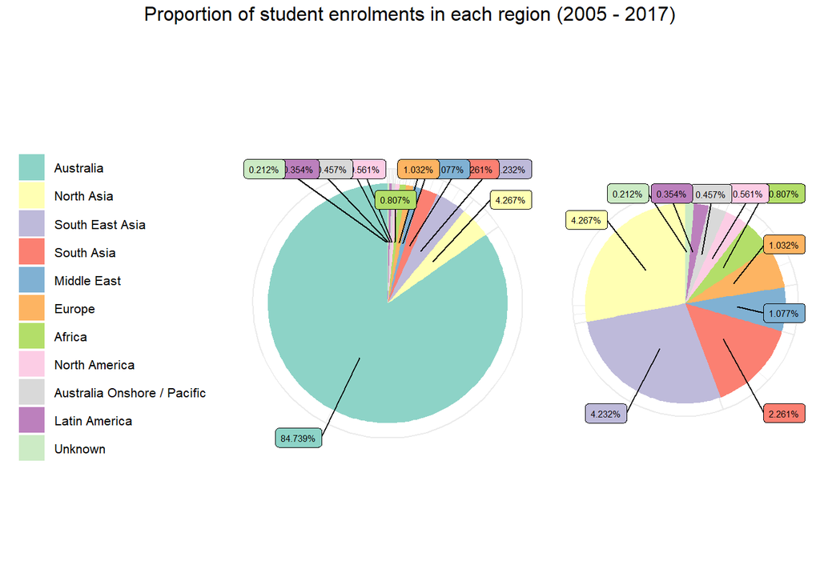

```r
region <- enrol2 %>%
  group_by(Region) %>%
  summarise(percent = n() / nrow(.) * 100)

region <- region[order(-region$percent),]
region$text <- 100 - (cumsum(region$percent) - region$percent/2)

reg1 <- ggplot(region, aes(x = 1, y = percent,
                 fill = reorder(Region, -text))) +
  geom_bar(stat = "identity") +
  geom_label_repel(aes(label = percent(percent/100), y = text),
                   size = 2, show.legend = F, nudge_x = 1) +
  scale_y_continuous(breaks = round(cumsum(rev(region$percent)), 1)) +
  coord_polar("y", start = 0) +
  theme_bw() +
  theme(axis.text = element_blank(),
        axis.title = element_blank(),
        axis.ticks = element_blank(),
        legend.position = "left",
        legend.title = element_blank(),
        legend.text = element_text(size = rel(0.7)),
        panel.border = element_blank()) +
  scale_fill_brewer(palette = "Set3")

reg2 <- ggplot(subset(region, Region != "Australia"), aes(x = 1, y = percent,
                 fill = reorder(Region, -text))) +
  geom_bar(stat = "identity") +
  geom_label_repel(aes(label = percent(percent/100), y = text),
                   size = 2, show.legend = F, nudge_x = 1) +
  scale_y_continuous(breaks = round(cumsum(rev(region$percent)), 1)) +
  coord_polar("y", start = 0) +
  theme_bw() +
  theme(axis.text = element_blank(),
        axis.ticks = element_blank(),
        axis.title = element_blank(),
        legend.position = "none",
        panel.border = element_blank()) +
  scale_fill_manual(values = c("#ffffb3", "#bebada", "#fb8072", "#80b1d3",
                               "#fdb462", "#b3de69", "#fccde5", "#d9d9d9",
                               "#bc80bd", "#ccebc5", "#ffed6f"))

grid.arrange(reg1, reg2, ncol = 2, widths = c(2,1),
             top = "Proportion of student enrolments in each region (2005 - 2017)")
```

```r
rm(reg1, reg2, region)
```

The pie chart on the left illustrates the proportion of student enrolments in each region including Australia, while the right pie chart represents the same information but excluding Australia.

Apart from Australia which holds the highest proportion of 84.7% of the data, North Asia, South East Asia and South Asia are the top 3 regions where the international students tend to come from, whereas Latin America, Australia Onshore/Pacific and North America are the bottom 3.

### SES

The *SES* column has multiple inconsistent fields, where we have ‘Not low SES’ and ‘Not Low SES’ represent the same group of students.

```r
summary(enrol2$SES)
```

```
##    Length     Class      Mode
##    120453 character character
```

Below is the code to clean the SES column:

```r
LowSES_str <- c("Low SES")
enrol2$SES <- ifelse((enrol2$SES %in% LowSES_str), "Low SES", "Not Low SES")
enrol2$SES <- as.factor(enrol2$SES)
summary(enrol2$SES)
```

```
##     Low SES Not Low SES
##       15862      104591
```

```r
rm(LowSES_str)
```

Now that the SES variable is clean, we can visualise the proportion of socioeconomic status within a year from 2005 to 2017 by using a filled bar chart.

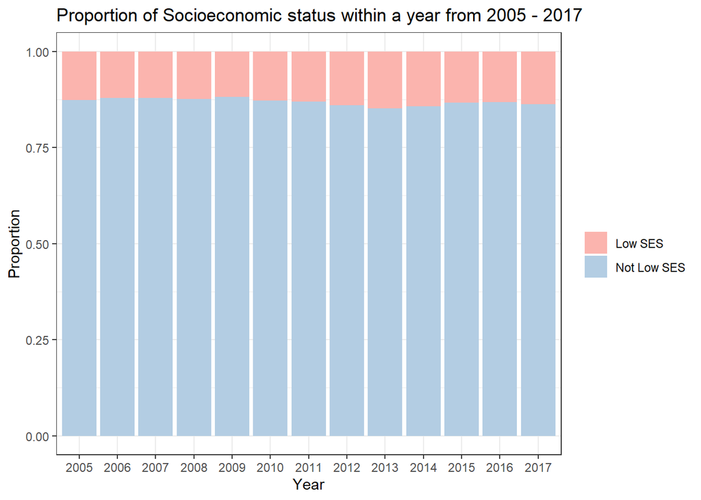

```r
ggplot(enrol2) +
  geom_bar(aes(fill = SES, x = Year),
           position = "fill") +
  labs(x = "Year", y = "Proportion", fill = "",
       title = "Proportion of Socioeconomic status within a year from 2005 - 2017") +
  scale_fill_brewer(palette = "Pastel1") +
  theme_bw()
```

### atar & ATAR_Group

The *atar* variable should be of type numeric. However, we can see that there are multiple unexpectedly large and small number, e.g. 1 and 999, which need to be cleaned. Let’s look at the summary and box plot of atar too spot the outliers.

```r
summary(enrol2$atar)
```

```
##    Min. 1st Qu.  Median    Mean 3rd Qu.    Max.    NA's
##     1.0     1.0     1.0   247.1    96.0   999.0   29128
```

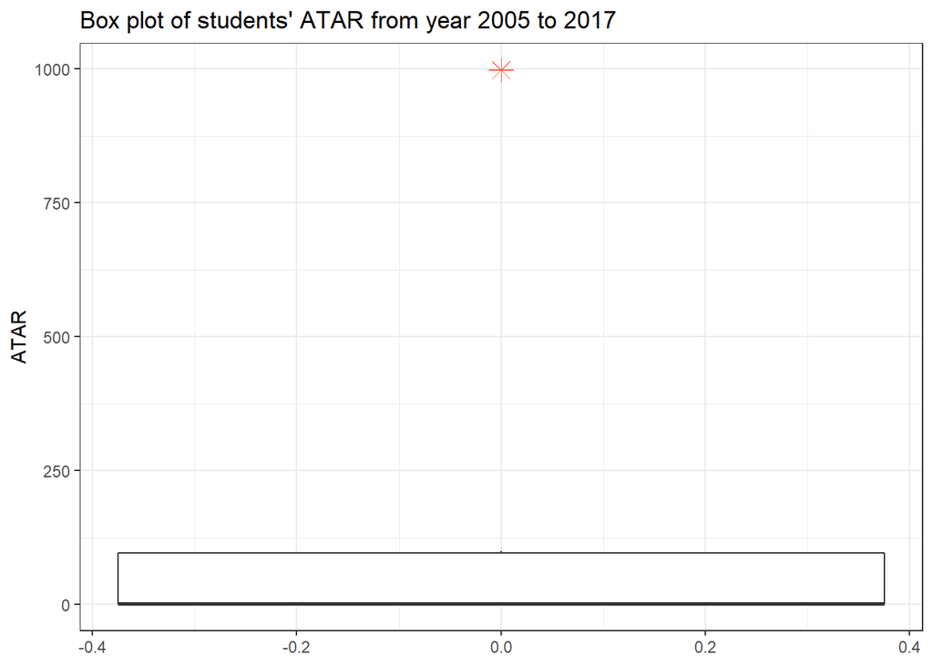

```r
ggplot(enrol2) +
  geom_boxplot(aes(y = atar), na.rm = TRUE,
                outlier.colour = "tomato", outlier.shape = 8, outlier.size = 4) +
  labs(y = "ATAR", title = "Box plot of students' ATAR from year 2005 to 2017") +
  theme_bw()
```

From the summary output and the box plot of students’ ATAR above, we can see that the minimum value, the first quartile and the median are all equal to one, whil the third quartile is equal to 96. The maximum value, however, goes all the way to 999, which is considered as an outlier. With the distribution like this, we can hardly do anything before we clean the outliers.

According to the [Australia Govenment Department of Education](https://heimshelp.education.gov.au/2018_data_requirements/2018dataelements/369), tertiary entrance score has a range from 30 to 100 and only apply for domestic students and students attempting or completed an Australian Year 12 examination/qualification prior to studying an undergraduate course. The atar equal to 1 mean that the student is not commencing an undergraduate course. The atar equal to 998 represents the student who iscommecing an undergraduate course or their ATAR score is not available. Lastly, for the students with atar equal to 999 means that the student is commencing an undergraduate course but not a domestic student and did not complete Australian Year 12.

| atar | meaning |
| --- | --- |
| 1 | Not undergraduate (UG) |
| 30 to 100 | Domestic & completed Year 12 |
| 998 | Undergraduate with no ATAR |
| 999 | Undergraduate, not domestic & not completed Year 12 |

Since, we will only investigate ATAR with domestic students who completed year 12, it is better to change other abnormal values to NA. The code chunk below will convert the atar which less than 30 or greater than 100 to NA and put it in the new column called **atar_fixed**.

```r
enrol2$atar_fixed <- ifelse(enrol2$atar < 30 | enrol2$atar > 100,
                            NA, as.numeric(enrol2$atar))
summary(enrol2$atar_fixed)
```

```
##    Min. 1st Qu.  Median    Mean 3rd Qu.    Max.    NA's
##      30      70      81      79      91     100  100641
```

Morover, we know that the ATAR values are missing systematically, converting it to categorical variable and rename NAs to Unknown will be a better approach. Luckily, the ATAR_Group attribute is provided with what we need. But before we decide to use ATAR_Group as a substitute of atar, we need to check whether the Unknown category in ATAR_Group match with NAs in atar.

```r
summary(enrol2$ATAR_Group)
```

```
##    Length     Class      Mode
##    120453 character character
```

The number of NAs/Unknown match but let’s check whether they come from the same location. The code chunk below create a binary column called **atar_check** which returns TRUE when the NAs-Unknown does match. Then we sum the column to see how many rows actually match.

```r
enrol2$atar_check <- ifelse(enrol2$ATAR_Group == "Unknown" & is.na(enrol2$atar_fixed), TRUE, FALSE)
sum(enrol2$atar_check)
```

```
## [1] 100641
```

```r
enrol2 <- select(enrol2, -c("atar_check"))
```

Since the number of rows that return TRUE in atar_check equal to the number of NAs/Unknown in atar and ATAR_Group, we can say that it is save to use ATAR_Group interchangeably with atar.

### mceetya, asgs, regionalremote_value & Regional

```r
summary(enrol2[,c("mceetya_regional_remote_count","asgs_regional_remote_count", "regionalremote_value", "Regional")])
```

```
##  mceetya_regional_remote_count asgs_regional_remote_count regionalremote_value
##  Min.   :0.00                  Min.   :0.00               Min.   :0.00
##  1st Qu.:0.00                  1st Qu.:0.00               1st Qu.:0.00
##  Median :0.00                  Median :0.00               Median :0.00
##  Mean   :0.16                  Mean   :0.17               Mean   :0.18
##  3rd Qu.:0.00                  3rd Qu.:0.00               3rd Qu.:0.00
##  Max.   :1.00                  Max.   :1.00               Max.   :1.00
##  NA's   :98891                 NA's   :88099              NA's   :101908
##    Regional
##  Length:120453
##  Class :character
##  Mode  :character
##
##
##
##
```

Notice that there is a large proportion of missing values in these variables and the number of NAs are not equal for all these columns. This is probably because MCEETYA classification was used up until 2011 and ASGS was employed after that. Hence, we cannot map these values into a category easily. Again, with the Regional attribute with substantially lower number of NAs provided, this might be a better choice than trying to find out what these missing values refer to.

The code chunk below will drop the **mceetya_regional_remote_count**, **asgs_regional_remote_count** and **regionalremote_value** from the data frame and rename NAs in **Regional** column to Unknown.

```r
enrol2 <- select(enrol2, select = -c("mceetya_regional_remote_count","asgs_regional_remote_count", "regionalremote_value"))

enrol2$Regional <- ifelse(is.na(enrol2$Regional), "Unknown",
                           ifelse(enrol2$Regional == "Not Regional/Remote", "Not Regional/Remote",
                                  ifelse(enrol2$Regional == "Regional/Remote", "Regional/Remote", "")))
enrol2$Regional <- as.factor(enrol2$Regional)
summary(enrol2$Regional)
```

```
## Not Regional/Remote     Regional/Remote             Unknown
##               71329               16770               32354
```

### onshore_indicator

The value of 0 in **onshore_indicator** represents Offshore, while the value of 1 indicates Onshore as stated by [Australia Government Department of Education](https://heimshelp.education.gov.au/dictionary/derived/945). Therefore we could rename these values. The onshore_indicator also have a lot of missing values, so we could rename this too.

```r
summary(enrol2$onshore_indicator)
```

```
##    Min. 1st Qu.  Median    Mean 3rd Qu.    Max.    NA's
##    0.00    1.00    1.00    0.98    1.00    1.00  100604
```

```r
enrol2$onshore_indicator <- ifelse(is.na(enrol2$onshore_indicator), "Unknown",
                                   ifelse(enrol2$onshore_indicator == 0, "Offshore" , "Onshore"))
enrol2$onshore_indicator <- as.factor(enrol2$onshore_indicator)
summary(enrol2$onshore_indicator)
```

```
## Offshore  Onshore  Unknown
##      298    19551   100604
```

# Visualisation

## Domestic VS overseas

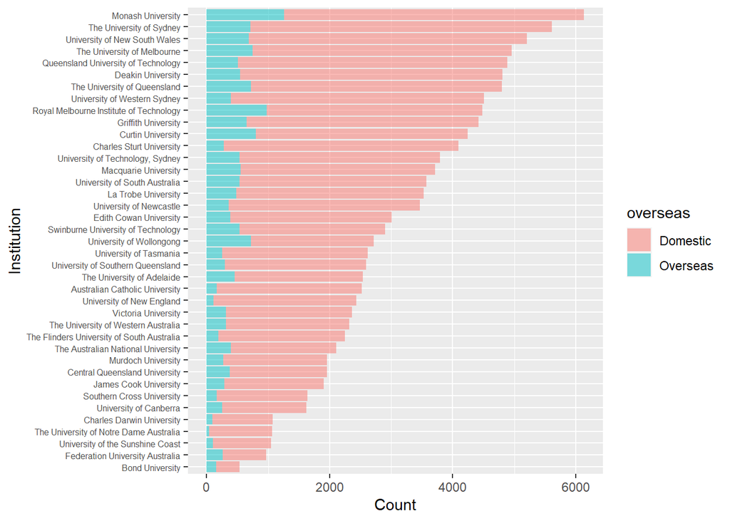

```r
ggplot(data = subset(enrol2,
                     Institution != "Australian Defence Force Academy" &
                       Institution != "Australian Maritime College")) +
  geom_bar(aes(x = reorder(Institution, Institution, length),
               fill = overseas), alpha = 0.5) +
  labs(y = "Count", x = "Institution") +
  coord_flip() +
  theme(axis.text.y = element_text(size = rel(0.7),
                                   vjust = 0.5,
                                   hjust = 1))
```

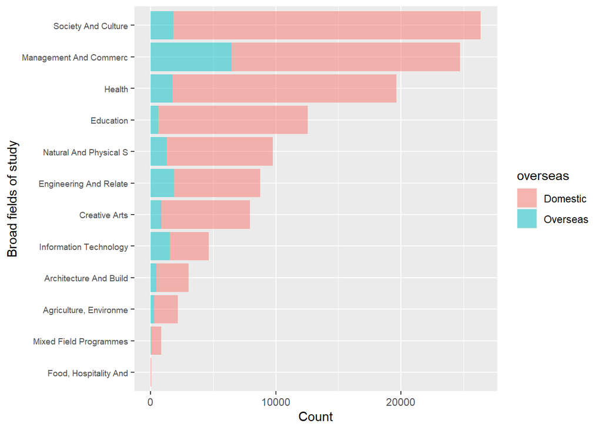

```r
ggplot(enrol2) +
  geom_bar(aes(x = reorder(broad_foe, broad_foe, length),
               fill = overseas), alpha = 0.5) +
  labs(y = "Count", x = "Broad fields of study") +
  coord_flip() +
  theme(axis.text.y = element_text(size = rel(0.8),
                                   vjust = 0.5,
                                   hjust = 1))
```

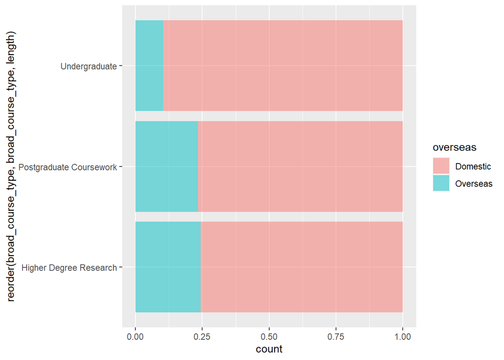

```r
ggplot(enrol2) +
  geom_bar(aes(x = reorder(broad_course_type, broad_course_type, length),
               fill = overseas), alpha = 0.5, position = "fill") +
  coord_flip() + theme(axis.text.y = element_text(vjust = 0.5, hjust = 1))
```

## ATAR

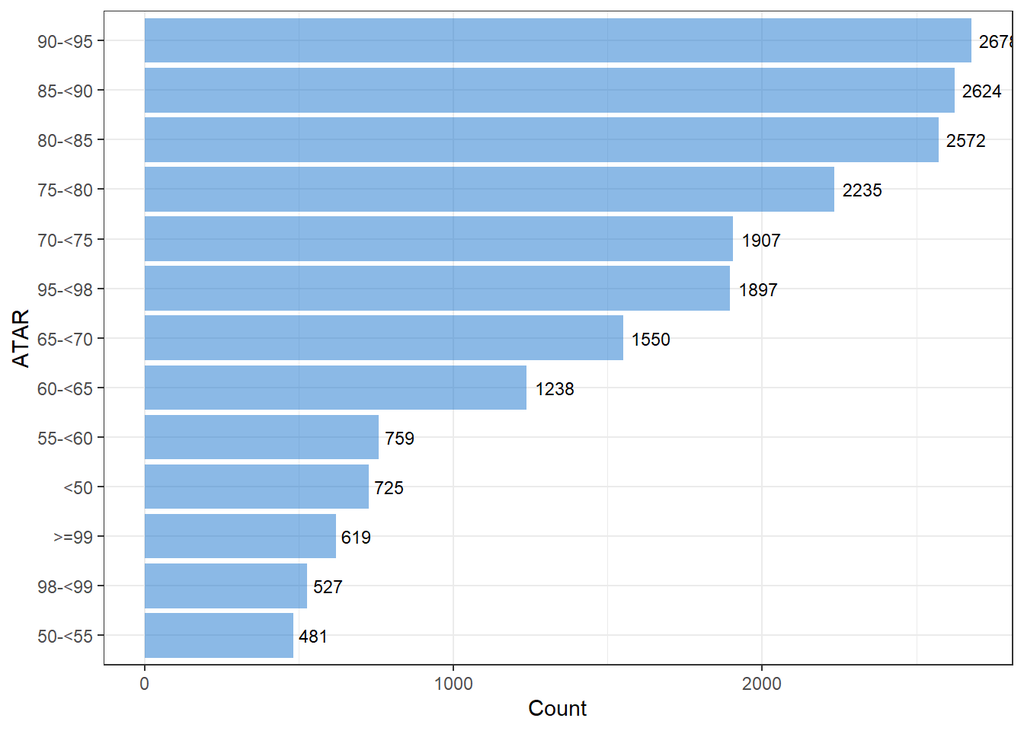

```r
ggplot(data = subset(enrol2, ATAR_Group != "Unknown"),
       aes(x = ATAR_Group)) +
  geom_bar(aes(x = reorder(ATAR_Group, ATAR_Group, length)),
           fill = "dodgerblue3", alpha = 0.5) +
  geom_text(stat = "count",  aes(label =..count..), vjust = 0.5, hjust = -0.2, size = 3) +
  labs(y = "Count", x = "ATAR") +
  theme_bw() +
  coord_flip() +
  theme(axis.text.y = element_text(vjust = 0.5, hjust = 1))
```

## Age VS Broad course type

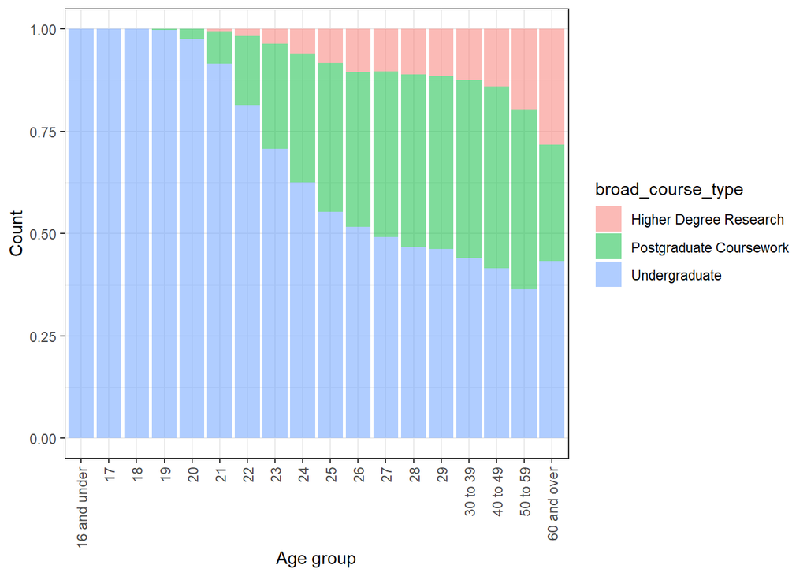

```r
ggplot(enrol2) +
  geom_bar(aes(x = age, fill = broad_course_type),
           alpha = 0.5, position = "fill") +
  theme_bw() +
  labs(x = "Age group", y = "Count") +
  theme(axis.text.x = element_text(angle = 90, vjust = 0.5, hjust = 1))
```

## UWA

If we want to investigate a variation of student enrolments at the University of Western Australia, we can plot a bar chart seperately. A bar chart of UWA student Enrolments proportion from year 2005 to 2017 is shown below:

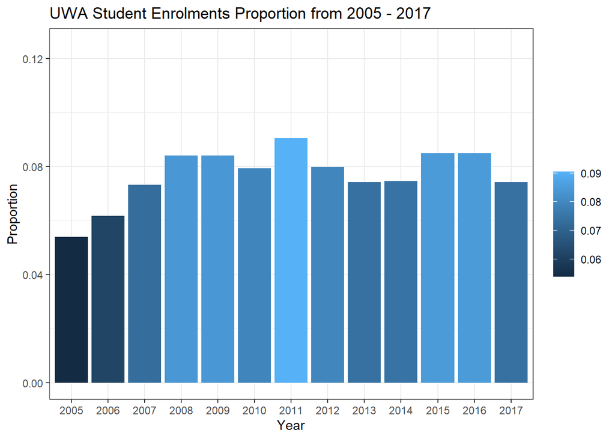

```r
enrol2$UWA <- ifelse(enrol2$Institution == "The University of Western Australia", TRUE, FALSE)
ggplot(subset(enrol2, UWA == TRUE), aes(x = Year)) +
  geom_bar(aes(y = ..prop.., group = 1, fill = ..prop..)) +
  scale_fill_gradient() +
  labs(x = "Year", y = "Proportion",
       title = "UWA Student Enrolments Proportion from 2005 - 2017",
       fill = "") +
  theme(legend.position = "none") +
  coord_cartesian(ylim = c(0,0.125)) +
  theme_bw()
```

The distribution of student enrolments at UWA tends to be increasing from year 2005 and reaching the highest proportion in 2011. Then, the proportion decreased in year 2012 and did not vary much afterwards.

# References

Australian Tertiary Admission Rank. (n.d.). Retrieved Septempber 5, 2019, from htps://en.wikipedia.org/wiki/Australian_Tertiary_Admission_Rank

Group of Eight Australia (n.d.). About Go8. Retrieved from https://go8.edu.au/about/the-go8

Studies in Australia. (n.d.). Australia compared. Retrieved from https://www.studiesinaustralia.com/studying-in-australia/why-study-in-australia/australia-compared

Australian Government: Department of Education (n.d.). 945 Onshore indicator. Retrieved from https://heimshelp.education.gov.au/dictionary/derived/945

Australian Government: Department of Education (n.d.). Field of Education Types. Retrieved from https://heimshelp.education.gov.au/resources/field-of-education-types

Australian Government: Department of Education (n.d.). Regional and Remote - Australian Statistical Geography Standard (ASGS) measure. Retrieved from https://heimshelp.education.gov.au/resources/glossary/glossarytermd7bd